# Richter's Predictor: Modeling Earthquake Damage

### Predicting Earthquake Building Damage Grades

## Problem Statement

On **25 April 2015**, a magnitude-7.8 earthquake struck Nepal. In its aftermath, Kathmandu Living Labs and the Central Bureau of Statistics (under Nepal's National Planning Commission) surveyed hundreds of thousands of buildings to record the damage each one sustained. Manually assessing every building at this scale is far too slow, so the goal of this project is to **predict a building's damage grade automatically** from its structural, geographic, and ownership characteristics.

The target, `damage_grade`, is an **ordinal** variable with three levels:

| Grade | Meaning |
| --- | --- |
| **1** | Low damage |
| **2** | Medium damage |
| **3** | Near-total destruction |

This is a **multi-class (ordinal) classification** problem built on one of the largest post-disaster survey datasets ever collected. It mixes heavily categorical structural features (foundation type, roof material, land surface condition, legal ownership) with hierarchical geo-location IDs and normalized numeric features, more real-world messiness than a typical tabular-ML dataset.

**Dataset at a glance**

|  | Rows | Columns |
| --- | --- | --- |
| `train_values` + `train_labels` | 260,601 | 39 |
| `test_values` | 86,868 | 39 |
| **Combined** | **347,469** | 75% / 25% train-test split |

Grade 2 alone accounts for ~57% of buildings, so the class distribution is **imbalanced**, and the target is **ordinal** (1 < 2 < 3). Both facts shape the modeling choices used later in this notebook: stratified sampling, class-imbalance-aware training, and comparing an ordinal-regression framing against standard multi-class classification.

## Feature Description

Each building is described by **38 features** (plus the `building_id` identifier), grouped as follows:

| Group | Count | Examples |
| --- | --- | --- |
| Geographic (hierarchical) | 3 | `geo_level_1_id` (0-30) -> `geo_level_2_id` (0-1427) -> `geo_level_3_id` (0-12567) |
| Numeric building characteristics | 5 | `count_floors_pre_eq`, `age`, `area_percentage`, `height_percentage`, `count_families` |
| Categorical building characteristics | 8 | `land_surface_condition`, `foundation_type`, `roof_type`, `ground_floor_type`, `other_floor_type`, `position`, `plan_configuration`, `legal_ownership_status` |
| Superstructure material flags (binary) | 11 | `has_superstructure_mud_mortar_stone`, `has_superstructure_timber`, `has_superstructure_rc_engineered`, ... |
| Secondary-use flags (binary) | 11 | `has_secondary_use` (umbrella) plus 10 sub-flags: `_agriculture`, `_hotel`, `_rental`, `_institution`, `_school`, `_industry`, `_health_post`, `_gov_office`, `_use_police`, `_other` |

The geo-location IDs form a **strict three-level hierarchy** (every `geo_level_3_id` nests inside exactly one `geo_level_2_id`, which nests inside exactly one `geo_level_1_id`), which is why they're target/frequency encoded rather than one-hot encoded. The 8 categorical columns are all low-cardinality (3-10 levels) and are one-hot encoded instead.

## Performance Metric

Because `damage_grade` is ordinal, this problem sits between classification and regression, it can be modeled either way. Performance is scored with the **micro-averaged F1 score**, which pools true/false positives and negatives across all three classes before computing precision and recall, avoiding the class-imbalance bias that plain accuracy (or macro-F1) would introduce:

$$ F_{micro} = \frac{2 \cdot P_{micro} \cdot R_{micro}}{P_{micro} + R_{micro}}, \qquad P_{micro} = \frac{\sum_{k=1}^{3} TP_k}{\sum_{k=1}^{3} (TP_k + FP_k)}, \qquad R_{micro} = \frac{\sum_{k=1}^{3} TP_k}{\sum_{k=1}^{3} (TP_k + FN_k)} $$

## Project Roadmap

#### A. Exploratory Data Analysis

1. Load the training features, training labels, and test features.
2. Confirm ID integrity: unique identifiers within each set, no overlap between train and test, and row-alignment between features and labels.
3. Inspect shape, columns, and dtypes.
4. Check missing values.
5. Check duplicate rows (full duplicates and feature-level duplicates).
6. Check invalid / sentinel values.
7. Analyse distributions of individual features.
8. Analyse the target variable: class balance / shape, and its implications for metric choice and cross-validation strategy.
9. Check cardinality and structure of any hierarchical or high-cardinality features -- this will decide encoding strategy later.
10. Check relationships / correlations between features and the target.
11. Summarise data-quality findings and their modeling implications.

#### B. Cleaning

12. Define deterministic cleaning rules from the EDA findings, separating row-dropping rules from capping/clipping rules.
13. Apply row-dropping rules to train only -- the test set has no label to justify a drop, and every test row must still receive a prediction.
14. Apply capping/clipping rules identically to train and test, using bounds derived from train only.

#### C. Preprocessing

15. Split features (X) and target (y) from the cleaned training set.
16. Build a preprocessing pipeline (encoders/scalers appropriate to each feature type).
17. Fit simple transformers on the training features only; if any encoder uses target information, fit it out-of-fold to avoid leakage.
18. Transform the training features.
19. Transform the held-out validation split and the test features using the transformer(s) fit on train only.

#### D. Model

20. Establish a naive baseline to contextualize later scores.
21. Train candidate models and compare via cross-validation on the competition metric.
22. Tune hyperparameters of the best candidate.
23. Refit the final model on the full cleaned training set.
24. Evaluate on a held-out split to check for systematic error patterns.
25. Predict on the test set, format the submission, and sanity-check the predicted distribution against train.

### Libraries import

```python
import os
from pathlib import Path

import numpy as np
import pandas as pd
import matplotlib.pyplot as plt
import matplotlib.ticker as mticker
import seaborn as sns
from scipy.stats import chi2_contingency

from sklearn.base import BaseEstimator, TransformerMixin
from sklearn.compose import ColumnTransformer
from sklearn.model_selection import StratifiedKFold
from sklearn.pipeline import Pipeline
from sklearn.preprocessing import OneHotEncoder, MinMaxScaler
from sklearn.utils.validation import check_is_fitted

pd.set_option("display.max_columns", None)
pd.set_option("display.width", 200)
pd.set_option("display.max_rows", 100)

print("Libraries all loaded to goooo!!!")
```

```
Libraries all loaded to goooo!!!
```

#### Path of the Dataset

```python
DATA_DIR = Path("../datasets")

TRAIN_VALUES_FILE = DATA_DIR / "train_values.csv"
TRAIN_LABELS_FILE = DATA_DIR / "train_labels.csv"
TEST_VALUES_FILE = DATA_DIR / "test_values.csv"
```

#### Data loading

```python
def load_data(data_dir: Path):
    """Load train_values, train_labels, and test_values from data_dir.

    Raises FileNotFoundError with a clear message if any expected file
    is missing, rather than failing on a downstream pandas error.
    """
    files = {
        "train_values": data_dir / "train_values.csv",
        "train_labels": data_dir / "train_labels.csv",
        "test_values": data_dir / "test_values.csv",
    }
    missing = [str(p) for p in files.values() if not p.exists()]
    if missing:
        raise FileNotFoundError(
            f"Expected data file(s) not found: {missing}. "
            f"Pass the correct folder with --data-dir."
        )

    train_values = pd.read_csv(files["train_values"])
    train_labels = pd.read_csv(files["train_labels"])
    test_values = pd.read_csv(files["test_values"])
    return train_values, train_labels, test_values


train_values, train_labels, test_values = load_data(DATA_DIR)

print("Data loaded successfully!")
```

```
Data loaded successfully!
```

```python
# Dataset sizes
train_size = len(train_values)
test_size = len(test_values)
total_size = train_size + test_size

# Calculate percentages
train_percentage = (train_size / total_size) * 100
test_percentage = (test_size / total_size) * 100

print("\nDataset Split")
print("=" * 50)
print(f"Training samples : {train_size:,}")
print(f"Test samples     : {test_size:,}")
print(f"Total samples    : {total_size:,}")
print("-" * 50)
print(f"Train ratio      : {train_size / total_size:.2%}")
print(f"Test ratio       : {test_size / total_size:.2%}")
```

```
Dataset Split
==================================================
Training samples : 260,601
Test samples     : 86,868
Total samples    : 347,469
--------------------------------------------------
Train ratio      : 75.00%
Test ratio       : 25.00%
```

#### Inspect the training features

```python
print("Train values shape:", train_values.shape)
print("Train labels shape:", train_labels.shape)
print("Test values shape:", test_values.shape)

print("\n--- Data types ---")
print(train_values.dtypes)

print("\n--- Missing values ---")
print(train_values.isnull().sum().sort_values(ascending=False))

print("\n--- Unique values ---")
print(train_values.nunique().sort_values(ascending=False))
```

```
Train values shape: (260601, 39)
Train labels shape: (260601, 2)
Test values shape: (86868, 39)

--- Data types ---
building_id                                int64
geo_level_1_id                             int64
geo_level_2_id                             int64
geo_level_3_id                             int64
count_floors_pre_eq                        int64
age                                        int64
area_percentage                            int64
height_percentage                          int64
land_surface_condition                    object
foundation_type                           object
roof_type                                 object
ground_floor_type                         object
other_floor_type                          object
position                                  object
plan_configuration                        object
has_superstructure_adobe_mud               int64
has_superstructure_mud_mortar_stone        int64
has_superstructure_stone_flag              int64
has_superstructure_cement_mortar_stone     int64
has_superstructure_mud_mortar_brick        int64
has_superstructure_cement_mortar_brick     int64
has_superstructure_timber                  int64
has_superstructure_bamboo                  int64
has_superstructure_rc_non_engineered       int64
has_superstructure_rc_engineered           int64
has_superstructure_other                   int64
legal_ownership_status                    object
count_families                             int64
has_secondary_use                          int64
has_secondary_use_agriculture              int64
has_secondary_use_hotel                    int64
has_secondary_use_rental                   int64
has_secondary_use_institution              int64
has_secondary_use_school                   int64
has_secondary_use_industry                 int64
```

[output cut: 74 more lines]

```
has_superstructure_rc_engineered               2
has_superstructure_rc_non_engineered           2
has_superstructure_other                       2
has_secondary_use                              2
has_secondary_use_agriculture                  2
has_secondary_use_hotel                        2
has_secondary_use_rental                       2
has_secondary_use_institution                  2
has_secondary_use_school                       2
has_secondary_use_industry                     2
has_secondary_use_health_post                  2
has_secondary_use_gov_office                   2
has_secondary_use_use_police                   2
has_secondary_use_other                        2
dtype: int64
```

#### Inspect the target

```python
print("\n--- Target columns ---")
print(train_labels.columns)

print("\n--- Target distribution ---")
print(train_labels["damage_grade"].value_counts())

print("\n--- Target proportions ---")
print(train_labels["damage_grade"].value_counts(normalize=True))
```

```
--- Target columns ---
Index(['building_id', 'damage_grade'], dtype='object')

--- Target distribution ---
damage_grade
2    148259
3     87218
1     25124
Name: count, dtype: int64

--- Target proportions ---
damage_grade
2    0.568912
3    0.334680
1    0.096408
Name: proportion, dtype: float64
```

#### Column groups (derived from the feature description document)

```python
ID_COL = "building_id"
TARGET_COL = "damage_grade"

GEO_COLS = ["geo_level_1_id", "geo_level_2_id", "geo_level_3_id"]

NUMERIC_COLS = [
    "count_floors_pre_eq",
    "age",
    "area_percentage",
    "height_percentage",
    "count_families",
]

CATEGORICAL_COLS = [
    "land_surface_condition",
    "foundation_type",
    "roof_type",
    "ground_floor_type",
    "other_floor_type",
    "position",
    "plan_configuration",
    "legal_ownership_status",
]

SUPERSTRUCTURE_COLS = [
    "has_superstructure_adobe_mud",
    "has_superstructure_mud_mortar_stone",
    "has_superstructure_stone_flag",
    "has_superstructure_cement_mortar_stone",
    "has_superstructure_mud_mortar_brick",
    "has_superstructure_cement_mortar_brick",
    "has_superstructure_timber",
    "has_superstructure_bamboo",
    "has_superstructure_rc_non_engineered",
    "has_superstructure_rc_engineered",
    "has_superstructure_other",
]

SECONDARY_USE_UMBRELLA_COL = "has_secondary_use"
SECONDARY_USE_SUB_COLS = [
    "has_secondary_use_agriculture",
    "has_secondary_use_hotel",
    "has_secondary_use_rental",
    "has_secondary_use_institution",
    "has_secondary_use_school",
    "has_secondary_use_industry",
    "has_secondary_use_health_post",
    "has_secondary_use_gov_office",
    "has_secondary_use_use_police",
    "has_secondary_use_other",
]
SECONDARY_USE_COLS = [SECONDARY_USE_UMBRELLA_COL] + SECONDARY_USE_SUB_COLS

BINARY_COLS = SUPERSTRUCTURE_COLS + SECONDARY_USE_COLS

# Fixed seed reused across EDA (mutual information) and preprocessing/modeling below.
RANDOM_STATE = 42
```

### Dataset Overview

This notebook explores the Nepal earthquake building-damage dataset. The goal is to predict `damage_grade` (1 = low, 2 = medium, 3 = heavy/destroyed) sustained by a building, based on its structural, geographic, and ownership characteristics.

The combined `train_values` + `test_values` set is **347,469** buildings, split **75% / 25%** into train and test (sizes confirmed below). The feature columns fall into five groups used throughout the analysis:

- **ID / Target:** `building_id`, `damage_grade`
- **Geographic (hierarchical):** `geo_level_1_id`, `geo_level_2_id`, `geo_level_3_id`
- **Numeric:** the geo levels plus `count_floors_pre_eq`, `age`, `area_percentage`, `height_percentage`, `count_families`
- **Categorical (8 columns):** `land_surface_condition`, `foundation_type`, `roof_type`, `ground_floor_type`, `other_floor_type`, `position`, `plan_configuration`, `legal_ownership_status`
- **Binary flags (22 columns):** 11 superstructure material indicators (e.g. `has_superstructure_mud_mortar_stone`) and 11 secondary-use flags (an umbrella `has_secondary_use` plus 10 sub-flags)

Sections 1-9 below check data quality, profile each feature group, and look at how each feature relates to `damage_grade`. Each plot is generated inline and also saved to `figures/` for reuse in reporting.

#### Utility

```python
def print_header(title: str):
    print("\n" + "=" * 80)
    print(title)
    print("=" * 80)
```

#### Plot styling setup

Shared palette, `rcParams`, and small helper functions used by every chart in the EDA sections below (colors follow the project's light-mode dataviz palette; ordinal `damage_grade` values use a sequential blue ramp, polarity/correlation charts use a diverging blue/red).

```python
# ---- palette (dataviz skill reference/palette.md, light mode) ----
INK_PRIMARY = "#0b0b0b"
INK_SECONDARY = "#52514e"
INK_MUTED = "#898781"
GRID = "#e1e0d9"
BASELINE = "#c3c2b7"
SURFACE = "#fcfcfb"

CAT = {
    "blue": "#2a78d6",
    "orange": "#eb6834",
    "aqua": "#1baf7a",
    "yellow": "#eda100",
    "magenta": "#e87ba4",
    "green": "#008300",
    "violet": "#4a3aa7",
    "red": "#e34948",
}
SEQ_BLUE = {100: "#cde2fb", 150: "#b7d3f6", 200: "#9ec5f4", 250: "#86b6ef",
            300: "#6da7ec", 350: "#5598e7", 400: "#3987e5", 450: "#2a78d6",
            500: "#256abf", 550: "#1c5cab", 600: "#184f95", 650: "#104281", 700: "#0d366b"}
DIVERGE_BLUE = "#2a78d6"
DIVERGE_RED = "#e34948"

# damage_grade is ordinal severity -> sequential blue ramp, reused across all Section 9 charts
GRADE_COLORS = {1: SEQ_BLUE[250], 2: SEQ_BLUE[450], 3: SEQ_BLUE[650]}

plt.rcParams.update({
    "figure.facecolor": SURFACE,
    "axes.facecolor": SURFACE,
    "savefig.facecolor": SURFACE,
    "font.family": "sans-serif",
    "font.sans-serif": ["Segoe UI", "Arial", "DejaVu Sans"],
    "text.color": INK_PRIMARY,
    "axes.edgecolor": BASELINE,
    "axes.labelcolor": INK_SECONDARY,
    "xtick.color": INK_MUTED,
    "ytick.color": INK_MUTED,
    "axes.grid": True,
    "grid.color": GRID,
    "grid.linewidth": 0.8,
    "axes.axisbelow": True,
    "font.size": 11,
})

OUT = Path("figures")
OUT.mkdir(parents=True, exist_ok=True)


def style_ax(ax, hide_spines=("top", "right", "left")):
    for s in hide_spines:
        ax.spines[s].set_visible(False)
    ax.spines["bottom"].set_color(BASELINE)


def bar_labels(ax, bars, fmt="{:,.0f}", color=INK_SECONDARY, pad=3, horizontal=False):
    for b in bars:
        if horizontal:
            w = b.get_width()
            ax.text(w + pad, b.get_y() + b.get_height() / 2, fmt.format(w),
                     va="center", ha="left", fontsize=9.5, color=color)
        else:
            h = b.get_height()
            ax.text(b.get_x() + b.get_width() / 2, h + pad, fmt.format(h),
                     va="bottom", ha="center", fontsize=9.5, color=color)


print("Plot styling ready. Figures will be saved to: ../assests/figures")
```

```
Plot styling ready. Figures will be saved to: ../assests/figures
```

#### Section 1: Shapes and key alignment

```python
print_header("1. DATASET SHAPES AND KEY ALIGNMENT")

print(
    f"train_values : {train_values.shape[0]:>7,} rows x "
    f"{train_values.shape[1]} columns"
)

print(
    f"train_labels : {train_labels.shape[0]:>7,} rows x "
    f"{train_labels.shape[1]} columns"
)

print(
    f"test_values  : {test_values.shape[0]:>7,} rows x "
    f"{test_values.shape[1]} columns"
)

print(
    f"\n{ID_COL} unique in train_values : "
    f"{train_values[ID_COL].is_unique}"
)

print(
    f"{ID_COL} unique in test_values  : "
    f"{test_values[ID_COL].is_unique}"
)

train_test_overlap = (
    set(train_values[ID_COL]) &
    set(test_values[ID_COL])
)

print(
    f"{ID_COL} overlap between train and test : "
    f"{len(train_test_overlap)}"
)

labels_aligned = (
    train_values[ID_COL].values ==
    train_labels[ID_COL].values
).all()

print(
    f"train_values / train_labels rows aligned by "
    f"{ID_COL} (same order) : {labels_aligned}"
)
```

```
================================================================================
1. DATASET SHAPES AND KEY ALIGNMENT
================================================================================
train_values : 260,601 rows x 39 columns
train_labels : 260,601 rows x 2 columns
test_values  :  86,868 rows x 39 columns

building_id unique in train_values : True
building_id unique in test_values  : True
building_id overlap between train and test : 0
train_values / train_labels rows aligned by building_id (same order) : True
```

**Interpretation:** The data is well-formed at the structural level -- no ID collisions between train and test, no duplicate IDs within either set, and the labels line up row-for-row with the feature table. No re-indexing or join is required before merging labels onto features.

#### Section 2: Missing values

```python
print_header("2. MISSING VALUES")

for name, df in [
    ("train_values", train_values),
    ("train_labels", train_labels),
    ("test_values", test_values)
]:
    n_missing = int(df.isnull().sum().sum())

    print(f"{name}: {n_missing} total missing values")

    if n_missing > 0:
        cols_with_na = df.isnull().sum()
        print(cols_with_na[cols_with_na > 0])
```

```
================================================================================
2. MISSING VALUES
================================================================================
train_values: 0 total missing values
train_labels: 0 total missing values
test_values: 0 total missing values
```

**Interpretation:** There is no missing-data problem anywhere in the dataset. No imputation strategy is needed -- this simplifies preprocessing considerably compared to a typical real-world tabular dataset.

#### Section 3: Duplicates

```python
print_header("3. DUPLICATE ROWS")

# Fully duplicated rows, including building_id
full_duplicate_rows = train_values[
    train_values.duplicated(keep=False)
]

# Feature-duplicate rows, excluding building_id
feature_duplicate_rows = train_values[
    train_values.drop(columns=[ID_COL])
    .duplicated(keep=False)
]

print(f"Fully duplicated rows              : {len(full_duplicate_rows):,}")
print(f"Duplicated feature rows            : {len(feature_duplicate_rows):,}")

if not full_duplicate_rows.empty:
    print("\n--- Fully duplicated rows ---")
    display(full_duplicate_rows)

print("\n--- Feature-duplicate rows ---")
display(feature_duplicate_rows.head())

print(
    "\nDifferent buildings can share an identical "
    "feature profile; this is expected given the "
    "categorical/binary-heavy feature space."
)
```

```
================================================================================
3. DUPLICATE ROWS
================================================================================
Fully duplicated rows              : 0
Duplicated feature rows            : 28,544

--- Feature-duplicate rows ---
```

|  | building_id | geo_level_1_id | geo_level_2_id | geo_level_3_id | count_floors_pre_eq | age | area_percentage | height_percentage | land_surface_condition | foundation_type | roof_type | ground_floor_type | other_floor_type | position | plan_configuration | has_superstructure_adobe_mud | has_superstructure_mud_mortar_stone | has_superstructure_stone_flag | has_superstructure_cement_mortar_stone | has_superstructure_mud_mortar_brick | has_superstructure_cement_mortar_brick | has_superstructure_timber | has_superstructure_bamboo | has_superstructure_rc_non_engineered | has_superstructure_rc_engineered | has_superstructure_other | legal_ownership_status | count_families | has_secondary_use | … |
| --- | --- | --- | --- | --- | --- | --- | --- | --- | --- | --- | --- | --- | --- | --- | --- | --- | --- | --- | --- | --- | --- | --- | --- | --- | --- | --- | --- | --- | --- | --- |
| 1 | 28830 | 8 | 900 | 2812 | 2 | 10 | 8 | 7 | o | r | n | x | q | s | d | 0 | 1 | 0 | 0 | 0 | 0 | 0 | 0 | 0 | 0 | 0 | v | 1 | 0 | … |
| 3 | 590882 | 22 | 418 | 10694 | 2 | 10 | 6 | 5 | t | r | n | f | x | s | d | 0 | 1 | 0 | 0 | 0 | 0 | 1 | 1 | 0 | 0 | 0 | v | 1 | 0 | … |
| 12 | 444381 | 12 | 335 | 8167 | 2 | 15 | 6 | 5 | t | r | n | x | x | s | d | 0 | 1 | 0 | 0 | 0 | 0 | 1 | 1 | 0 | 0 | 0 | v | 1 | 0 | … |
| 18 | 354011 | 26 | 1401 | 3904 | 1 | 20 | 12 | 3 | t | u | n | v | j | s | d | 0 | 0 | 0 | 0 | 0 | 1 | 0 | 0 | 0 | 0 | 0 | v | 1 | 0 | … |
| 48 | 987864 | 10 | 1097 | 399 | 2 | 20 | 7 | 4 | t | r | q | f | q | s | d | 0 | 1 | 0 | 0 | 0 | 0 | 0 | 0 | 0 | 0 | 0 | v | 1 | 0 | … |

```
Different buildings can share an identical feature profile; this is expected given the categorical/binary-heavy feature space.
```

```python
duplicate_features = (
    train_values
    .drop(columns=[ID_COL])
    .duplicated(keep=False)
)

duplicates = train_values[duplicate_features].copy()

display(
    duplicates.sort_values(
        by=train_values.columns.tolist()
    )
)

duplicate_analysis = (
    train_values[duplicate_features]
    .merge(train_labels, on=ID_COL)
)

display(duplicate_analysis)
```

|  | building_id | geo_level_1_id | geo_level_2_id | geo_level_3_id | count_floors_pre_eq | age | area_percentage | height_percentage | land_surface_condition | foundation_type | roof_type | ground_floor_type | other_floor_type | position | plan_configuration | has_superstructure_adobe_mud | has_superstructure_mud_mortar_stone | has_superstructure_stone_flag | has_superstructure_cement_mortar_stone | has_superstructure_mud_mortar_brick | has_superstructure_cement_mortar_brick | has_superstructure_timber | has_superstructure_bamboo | has_superstructure_rc_non_engineered | has_superstructure_rc_engineered | has_superstructure_other | legal_ownership_status | count_families | has_secondary_use | … |
| --- | --- | --- | --- | --- | --- | --- | --- | --- | --- | --- | --- | --- | --- | --- | --- | --- | --- | --- | --- | --- | --- | --- | --- | --- | --- | --- | --- | --- | --- | --- |
| 25045 | 17 | 3 | 1387 | 3909 | 5 | 40 | 5 | 10 | t | r | n | f | q | o | d | 0 | 0 | 0 | 0 | 1 | 0 | 0 | 0 | 0 | 0 | 0 | v | 1 | 0 | … |
| 234432 | 25 | 26 | 1132 | 6645 | 2 | 0 | 6 | 6 | t | w | n | f | x | s | d | 0 | 0 | 0 | 0 | 0 | 0 | 1 | 0 | 0 | 0 | 0 | a | 1 | 0 | … |
| 228351 | 28 | 8 | 1297 | 9721 | 2 | 0 | 2 | 6 | t | r | n | f | x | s | d | 0 | 1 | 1 | 0 | 0 | 0 | 0 | 0 | 0 | 0 | 0 | v | 1 | 0 | … |
| 50540 | 40 | 10 | 1174 | 9536 | 2 | 20 | 5 | 5 | t | r | q | f | q | s | d | 0 | 1 | 0 | 0 | 0 | 0 | 0 | 0 | 0 | 0 | 0 | v | 1 | 0 | … |
| 45235 | 42 | 10 | 803 | 5136 | 2 | 15 | 5 | 5 | t | r | n | x | q | s | d | 0 | 1 | 0 | 0 | 0 | 0 | 1 | 0 | 0 | 0 | 0 | v | 1 | 0 | … |
| ... | ... | ... | ... | ... | ... | ... | ... | ... | ... | ... | ... | ... | ... | ... | ... | ... | ... | ... | ... | ... | ... | ... | ... | ... | ... | ... | ... | ... | ... | … |
| 169368 | 1052826 | 7 | 675 | 4736 | 2 | 15 | 7 | 4 | t | r | n | f | x | s | d | 0 | 1 | 0 | 0 | 0 | 0 | 1 | 0 | 0 | 0 | 0 | v | 1 | 0 | … |
| 27035 | 1052880 | 6 | 845 | 7126 | 2 | 5 | 6 | 5 | t | r | n | f | q | s | d | 0 | 1 | 0 | 0 | 0 | 0 | 0 | 0 | 0 | 0 | 0 | v | 1 | 0 | … |
| 244305 | 1052897 | 1 | 907 | 6930 | 2 | 10 | 2 | 4 | t | w | n | f | q | s | d | 0 | 1 | 0 | 0 | 0 | 0 | 0 | 0 | 0 | 0 | 0 | v | 1 | 0 | … |
| 155741 | 1052899 | 22 | 726 | 10485 | 2 | 5 | 12 | 6 | t | r | n | f | q | t | d | 0 | 1 | 0 | 0 | 0 | 0 | 0 | 0 | 0 | 0 | 0 | v | 1 | 0 | … |
| 148331 | 1052915 | 10 | 1007 | 10666 | 2 | 40 | 5 | 4 | t | r | n | f | q | s | d | 0 | 1 | 0 | 0 | 0 | 0 | 0 | 0 | 0 | 0 | 0 | v | 1 | 0 | … |

28544 rows × 39 columns

|  | building_id | geo_level_1_id | geo_level_2_id | geo_level_3_id | count_floors_pre_eq | age | area_percentage | height_percentage | land_surface_condition | foundation_type | roof_type | ground_floor_type | other_floor_type | position | plan_configuration | has_superstructure_adobe_mud | has_superstructure_mud_mortar_stone | has_superstructure_stone_flag | has_superstructure_cement_mortar_stone | has_superstructure_mud_mortar_brick | has_superstructure_cement_mortar_brick | has_superstructure_timber | has_superstructure_bamboo | has_superstructure_rc_non_engineered | has_superstructure_rc_engineered | has_superstructure_other | legal_ownership_status | count_families | has_secondary_use | … |
| --- | --- | --- | --- | --- | --- | --- | --- | --- | --- | --- | --- | --- | --- | --- | --- | --- | --- | --- | --- | --- | --- | --- | --- | --- | --- | --- | --- | --- | --- | --- |
| 0 | 28830 | 8 | 900 | 2812 | 2 | 10 | 8 | 7 | o | r | n | x | q | s | d | 0 | 1 | 0 | 0 | 0 | 0 | 0 | 0 | 0 | 0 | 0 | v | 1 | 0 | … |
| 1 | 590882 | 22 | 418 | 10694 | 2 | 10 | 6 | 5 | t | r | n | f | x | s | d | 0 | 1 | 0 | 0 | 0 | 0 | 1 | 1 | 0 | 0 | 0 | v | 1 | 0 | … |
| 2 | 444381 | 12 | 335 | 8167 | 2 | 15 | 6 | 5 | t | r | n | x | x | s | d | 0 | 1 | 0 | 0 | 0 | 0 | 1 | 1 | 0 | 0 | 0 | v | 1 | 0 | … |
| 3 | 354011 | 26 | 1401 | 3904 | 1 | 20 | 12 | 3 | t | u | n | v | j | s | d | 0 | 0 | 0 | 0 | 0 | 1 | 0 | 0 | 0 | 0 | 0 | v | 1 | 0 | … |
| 4 | 987864 | 10 | 1097 | 399 | 2 | 20 | 7 | 4 | t | r | q | f | q | s | d | 0 | 1 | 0 | 0 | 0 | 0 | 0 | 0 | 0 | 0 | 0 | v | 1 | 0 | … |
| ... | ... | ... | ... | ... | ... | ... | ... | ... | ... | ... | ... | ... | ... | ... | ... | ... | ... | ... | ... | ... | ... | ... | ... | ... | ... | ... | ... | ... | ... | … |
| 28539 | 333974 | 7 | 1306 | 2696 | 2 | 10 | 6 | 5 | t | r | n | z | x | s | d | 0 | 0 | 1 | 0 | 0 | 0 | 0 | 0 | 0 | 0 | 0 | v | 1 | 0 | … |
| 28540 | 29215 | 4 | 144 | 5751 | 2 | 5 | 4 | 4 | t | r | q | x | q | s | d | 0 | 1 | 0 | 0 | 0 | 0 | 1 | 0 | 0 | 0 | 0 | v | 1 | 0 | … |
| 28541 | 262990 | 17 | 875 | 10462 | 2 | 5 | 6 | 5 | t | r | n | f | q | s | d | 0 | 1 | 0 | 0 | 0 | 0 | 0 | 0 | 0 | 0 | 0 | v | 1 | 0 | … |
| 28542 | 192421 | 7 | 322 | 2843 | 2 | 10 | 6 | 6 | t | r | n | f | q | s | d | 1 | 1 | 0 | 0 | 0 | 0 | 1 | 0 | 0 | 0 | 0 | v | 1 | 0 | … |
| 28543 | 827012 | 8 | 268 | 4718 | 2 | 20 | 8 | 5 | t | r | n | f | q | s | d | 0 | 1 | 0 | 0 | 0 | 0 | 0 | 0 | 0 | 0 | 0 | v | 1 | 0 | … |

28544 rows × 40 columns

**Interpretation:** No two rows are true duplicates (every `building_id` is unique), but **28,544 rows (~11% of train)** share an identical feature profile with at least one other building. This is expected: the feature space is dominated by low-cardinality categorical and binary columns, so many structurally similar buildings (same foundation, same floor counts, same materials, same location bucket) will look identical on features alone even though they are genuinely different buildings. This is not a data-quality defect and rows were not dropped solely on this basis, although it is revisited during the outlier/cleaning pass later in the notebook.

#### Section 4: Target distribution

```python
print_header(f"4. TARGET DISTRIBUTION ({TARGET_COL})")

counts = (
    train_labels[TARGET_COL]
    .value_counts()
    .sort_index()
)

pct = (
    train_labels[TARGET_COL]
    .value_counts(normalize=True)
    .sort_index() * 100
)

summary = pd.DataFrame({
    "count": counts,
    "pct": pct.round(2)
})

display(summary)

print(
    "\nClass imbalance confirmed: grade 2 dominates, "
    "grade 1 is a clear minority."
)

print(
    "Accuracy can therefore be misleading; "
    "micro-F1 is the intended optimisation metric."
)
```

```
================================================================================
4. TARGET DISTRIBUTION (damage_grade)
================================================================================
```

| damage_grade | count | pct |
| --- | --- | --- |
| 1 | 25124 | 9.64 |
| 2 | 148259 | 56.89 |
| 3 | 87218 | 33.47 |

```
Class imbalance confirmed: grade 2 dominates, grade 1 is a clear minority.
Accuracy can therefore be misleading; micro-F1 is the intended optimisation metric.
```

#### Plot: target distribution

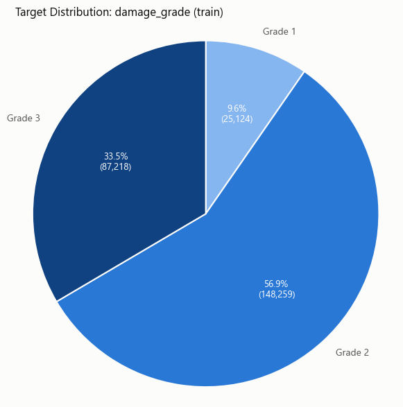

```python
fig, ax = plt.subplots(figsize=(6, 6))
wedges, _, autotexts = ax.pie(
    counts.values,
    labels=[f"Grade {g}" for g in counts.index],
    colors=[GRADE_COLORS[g] for g in counts.index],
    autopct=lambda p: f"{p:.1f}%\n({int(round(p / 100 * counts.sum())):,})",
    startangle=90,
    counterclock=False,
    wedgeprops=dict(edgecolor=SURFACE, linewidth=1.5),
    textprops=dict(color=INK_SECONDARY, fontsize=10),
)
for at in autotexts:
    at.set_color("white")
    at.set_fontsize(9.5)
ax.set_title("Target Distribution: damage_grade (train)", color=INK_PRIMARY, fontsize=12, loc="left", pad=12)
ax.axis("equal")
plt.tight_layout()
plt.savefig(OUT / "target_distribution_pie.png", dpi=160)
plt.show()
```

**Interpretation:** The target is **imbalanced** -- grade 2 accounts for well over half of all buildings, while grade 1 is a clear minority class (< 10%). This has two direct modeling consequences:

- **Accuracy is a misleading metric** -- a model that always predicts grade 2 would score ~57% accuracy while being useless for grades 1 and 3.
- **Micro-F1** (the competition's actual scoring metric) is the appropriate objective, and class-imbalance-aware techniques (class weighting, stratified sampling/CV, appropriate encoding) should be used.

#### Section 5: Geographic features

```python
print_header("5. GEOGRAPHIC FEATURES (geo_level_1/2/3_id)")

all_values = pd.concat(
    [
        train_values[GEO_COLS],
        test_values[GEO_COLS]
    ],
    axis=0,
    ignore_index=True
)

print("Cardinality (train + test combined):")

for col in GEO_COLS:
    print(
        f"  {col:<16} "
        f"unique={all_values[col].nunique():>6}  "
        f"min={all_values[col].min():>6}  "
        f"max={all_values[col].max():>6}"
    )

g2_to_g1 = (
    all_values
    .groupby("geo_level_2_id")["geo_level_1_id"]
    .nunique()
)

g3_to_g2 = (
    all_values
    .groupby("geo_level_3_id")["geo_level_2_id"]
    .nunique()
)

print("\nHierarchy nesting consistency:")

print(
    "  geo_level_2_id values mapping to >1 "
    f"geo_level_1_id : {(g2_to_g1 > 1).sum()} / "
    f"{len(g2_to_g1)}"
)

print(
    "  geo_level_3_id values mapping to >1 "
    f"geo_level_2_id : {(g3_to_g2 > 1).sum()} / "
    f"{len(g3_to_g2)}"
)

print(
    "\nTest-set categories unseen in train "
    "(relevant for encoding strategy):"
)

for col in GEO_COLS:
    train_ids = set(train_values[col].unique())
    test_ids = set(test_values[col].unique())

    unseen = test_ids - train_ids

    print(
        f"  {col:<16} "
        f"unseen={len(unseen):>5} / "
        f"{len(test_ids)} test-side unique values"
    )
```

```
================================================================================
5. GEOGRAPHIC FEATURES (geo_level_1/2/3_id)
================================================================================
Cardinality (train + test combined):
  geo_level_1_id   unique=    31  min=     0  max=    30
  geo_level_2_id   unique=  1418  min=     0  max=  1427
  geo_level_3_id   unique= 11861  min=     0  max= 12567

Hierarchy nesting consistency:
  geo_level_2_id values mapping to >1 geo_level_1_id : 0 / 1418
  geo_level_3_id values mapping to >1 geo_level_2_id : 0 / 11861

Test-set categories unseen in train (relevant for encoding strategy):
  geo_level_1_id   unseen=    0 / 31 test-side unique values
  geo_level_2_id   unseen=    4 / 1364 test-side unique values
  geo_level_3_id   unseen=  266 / 10213 test-side unique values
```

#### Plot: geographic hierarchy cardinality

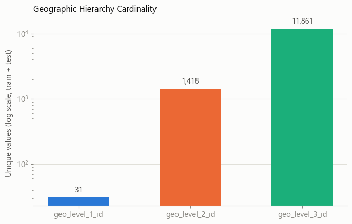

```python
uniq = [all_values[c].nunique() for c in GEO_COLS]
geo_labels = ["geo_level_1_id", "geo_level_2_id", "geo_level_3_id"]
colors3 = [CAT["blue"], CAT["orange"], CAT["aqua"]]

fig, ax = plt.subplots(figsize=(7, 4.5))
bars = ax.bar(geo_labels, uniq, color=colors3, width=0.55)
ax.set_yscale("log")
for b, v in zip(bars, uniq):
    ax.text(b.get_x() + b.get_width() / 2, b.get_height() * 1.12, f"{v:,}",
            ha="center", va="bottom", fontsize=10.5, color=INK_SECONDARY)
ax.set_ylabel("Unique values (log scale, train + test)")
ax.set_title("Geographic Hierarchy Cardinality", color=INK_PRIMARY, fontsize=12, loc="left", pad=12)
style_ax(ax)
ax.grid(axis="x", visible=False)
plt.tight_layout()
plt.savefig(OUT / "geo_cardinality.png", dpi=160)
plt.show()
```

**Interpretation:** The three geo levels form a **clean, perfectly nested hierarchy** (each `geo_level_3_id` sits under exactly one `geo_level_2_id`, and each of those under exactly one `geo_level_1_id`), with no cross-contamination between branches. However, cardinality explodes at the finest level (`geo_level_3_id` has ~11,861 distinct values), and a non-trivial number of `geo_level_3_id` values in the test set (266, or ~2.6% of test-side unique values) were **never seen during training**. This rules out simple one-hot encoding for the geo columns and motivates the **out-of-fold target encoding** approach used later in the preprocessing pipeline, which degrades gracefully to a smoothed prior for unseen categories rather than failing outright.

#### Section 6: Numeric features

```python
print_header("6. NUMERIC FEATURE SUMMARY")

display(
    train_values[NUMERIC_COLS]
    .describe()
    .T
)

age_995 = int(
    (train_values["age"] == 995).sum()
)

age_ge_200 = int(
    (train_values["age"] >= 200).sum()
)

print(
    f"\n'age' outlier flag: {age_995} rows equal 995 "
    f"({age_ge_200} rows are >= 200 in total)."
)

print(
    "This looks like a placeholder/censored code "
    "rather than a genuine measurement."
)
```

```
================================================================================
6. NUMERIC FEATURE SUMMARY
================================================================================
```

|  | count | mean | std | min | 25% | 50% | 75% | max |
| --- | --- | --- | --- | --- | --- | --- | --- | --- |
| geo_level_1_id | 260601.0 | 13.900353 | 8.033617 | 0.0 | 7.0 | 12.0 | 21.0 | 30.0 |
| geo_level_2_id | 260601.0 | 701.074685 | 412.710734 | 0.0 | 350.0 | 702.0 | 1050.0 | 1427.0 |
| geo_level_3_id | 260601.0 | 6257.876148 | 3646.369645 | 0.0 | 3073.0 | 6270.0 | 9412.0 | 12567.0 |
| count_floors_pre_eq | 260601.0 | 2.129723 | 0.727665 | 1.0 | 2.0 | 2.0 | 2.0 | 9.0 |
| age | 260601.0 | 26.535029 | 73.565937 | 0.0 | 10.0 | 15.0 | 30.0 | 995.0 |
| area_percentage | 260601.0 | 8.018051 | 4.392231 | 1.0 | 5.0 | 7.0 | 9.0 | 100.0 |
| height_percentage | 260601.0 | 5.434365 | 1.918418 | 2.0 | 4.0 | 5.0 | 6.0 | 32.0 |
| count_families | 260601.0 | 0.983949 | 0.418389 | 0.0 | 1.0 | 1.0 | 1.0 | 9.0 |

```
'age' outlier flag: 1390 rows equal 995 (1496 rows are >= 200 in total).
This looks like a placeholder/censored code rather than a genuine measurement.
```

#### Plot: age distribution and continuous-feature outliers

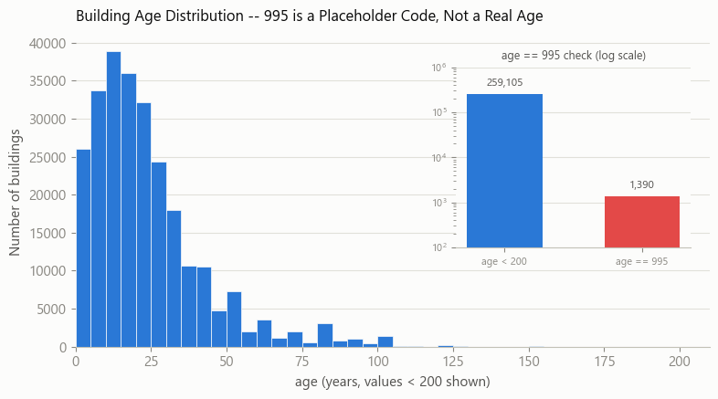

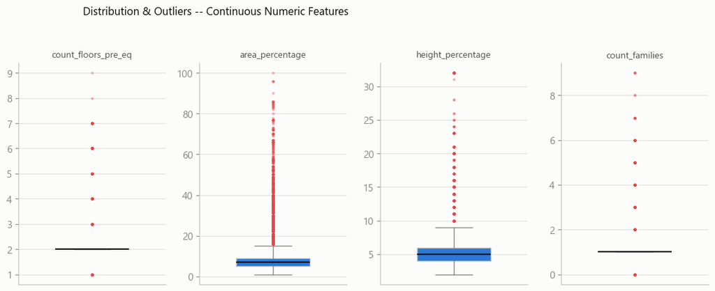

```python
age = train_values["age"]
fig, ax = plt.subplots(figsize=(8, 4.5))
ax.hist(age[age < 200], bins=range(0, 205, 5), color=CAT["blue"], edgecolor=SURFACE, linewidth=0.5)
ax.set_xlim(0, 210)
ax2 = ax.inset_axes([0.60, 0.32, 0.37, 0.58])
n995 = int((age == 995).sum())
vals995 = [int((age < 200).sum()), n995]
ax2.bar([0, 1], vals995, color=[CAT["blue"], CAT["red"]], width=0.55)
ax2.set_yscale("log")
ax2.set_ylim(100, 1_000_000)
ax2.set_xticks([0, 1])
ax2.set_xticklabels(["age < 200", "age == 995"], fontsize=8)
for i, v in enumerate(vals995):
    ax2.text(i, v * 1.3, f"{v:,}", ha="center", va="bottom", fontsize=8.5, color=INK_SECONDARY)
ax2.set_title("age == 995 check (log scale)", fontsize=9, color=INK_SECONDARY)
ax2.tick_params(labelsize=8)
style_ax(ax2)
ax2.grid(axis="x", visible=False)
ax.set_xlabel("age (years, values < 200 shown)")
ax.set_ylabel("Number of buildings")
ax.set_title("Building Age Distribution -- 995 is a Placeholder Code, Not a Real Age",
             color=INK_PRIMARY, fontsize=12, loc="left", pad=12)
style_ax(ax)
ax.grid(axis="x", visible=False)
plt.tight_layout()
plt.savefig(OUT / "age_distribution.png", dpi=160)
plt.show()

cols = ["count_floors_pre_eq", "area_percentage", "height_percentage", "count_families"]
fig, axes = plt.subplots(1, 4, figsize=(11, 4.5))
for ax, col in zip(axes, cols):
    ax.boxplot(train_values[col], vert=True, widths=0.5, patch_artist=True,
               boxprops=dict(facecolor=CAT["blue"], color=BASELINE),
               medianprops=dict(color=INK_PRIMARY, linewidth=1.5),
               whiskerprops=dict(color=INK_MUTED),
               capprops=dict(color=INK_MUTED),
               flierprops=dict(marker="o", markersize=3, markerfacecolor=CAT["red"],
                                markeredgecolor="none", alpha=0.4))
    ax.set_title(col, fontsize=10, color=INK_SECONDARY)
    ax.set_xticks([])
    style_ax(ax, hide_spines=("top", "right"))
    ax.grid(axis="x", visible=False)
fig.suptitle("Distribution & Outliers -- Continuous Numeric Features", color=INK_PRIMARY, fontsize=12, x=0.12, ha="left")
plt.tight_layout(rect=[0, 0, 1, 0.94])
plt.savefig(OUT / "numeric_boxplots.png", dpi=160)
plt.show()
```

**Interpretation:** `age`'s maximum value of 995 combined with a standard deviation (73.6) that dwarfs the median (15) is a strong signal that **995 is a placeholder/censoring code** (e.g. "unknown" or "very old, capped") rather than a genuine building age. Its presence heavily skews the distribution and is treated as an outlier to be removed at the cleaning stage rather than a real measurement. The other numeric columns look reasonably well-behaved, though `area_percentage` and `height_percentage` still show long right tails worth checking with IQR-based outlier detection (done later in the notebook).

#### Section 7: Categorical Features & Their Relationship with Damage Grade

```python
print_header("7. CATEGORICAL FEATURE VALUE COUNTS")

for col in CATEGORICAL_COLS:

    print(
        f"\n--- {col} "
        f"({train_values[col].nunique()} unique in train) ---"
    )

    display(
        train_values[col]
        .value_counts()
        .to_frame("count")
    )

    train_set = set(train_values[col].unique())
    test_set = set(test_values[col].unique())

    unseen = test_set - train_set

    if unseen:
        print(f"Unseen categories in test: {unseen}")
    else:
        print("No unseen categories in test.")
```

```
================================================================================
7. CATEGORICAL FEATURE VALUE COUNTS
================================================================================

--- land_surface_condition (3 unique in train) ---
```

| land_surface_condition | count |
| --- | --- |
| t | 216757 |
| n | 35528 |
| o | 8316 |

```
No unseen categories in test.

--- foundation_type (5 unique in train) ---
```

| foundation_type | count |
| --- | --- |
| r | 219196 |
| w | 15118 |
| u | 14260 |
| i | 10579 |
| h | 1448 |

```
No unseen categories in test.

--- roof_type (3 unique in train) ---
```

| roof_type | count |
| --- | --- |
| n | 182842 |
| q | 61576 |
| x | 16183 |

```
No unseen categories in test.

--- ground_floor_type (5 unique in train) ---
```

| ground_floor_type | count |
| --- | --- |
| f | 209619 |
| x | 24877 |
| v | 24593 |
| z | 1004 |
| m | 508 |

```
No unseen categories in test.

--- other_floor_type (4 unique in train) ---
```

| other_floor_type | count |
| --- | --- |
| q | 165282 |
| x | 43448 |
| j | 39843 |
| s | 12028 |

```
No unseen categories in test.

--- position (4 unique in train) ---
```

| position | count |
| --- | --- |
| s | 202090 |
| t | 42896 |
| j | 13282 |
| o | 2333 |

```
No unseen categories in test.

--- plan_configuration (10 unique in train) ---
```

| plan_configuration | count |
| --- | --- |
| d | 250072 |
| q | 5692 |
| u | 3649 |
| s | 346 |
| c | 325 |
| a | 252 |
| o | 159 |
| m | 46 |
| n | 38 |
| f | 22 |

```
No unseen categories in test.

--- legal_ownership_status (4 unique in train) ---
```

| legal_ownership_status | count |
| --- | --- |
| v | 250939 |
| a | 5512 |
| w | 2677 |
| r | 1473 |

```
No unseen categories in test.
```

**Interpretation:** Every categorical column is **low cardinality (3-10 levels)** and, importantly, **no unseen categories appear in test for any of these 8 columns** -- unlike the geo levels. This makes one-hot encoding a safe, low-risk choice for these columns (as used later in preprocessing). Several columns are heavily dominated by a single category (e.g. `foundation_type = r` at 84%, `plan_configuration = d` at 96%, `legal_ownership_status = v` at 96%), meaning the discriminative signal in these columns is concentrated in the minority levels.

```python
df = train_values.merge(train_labels, on=ID_COL)  # used by every relationship-with-target plot below
```

#### `foundation_type`

**Description:** Type of foundation used while building. *(categorical; possible values: `h`, `i`, `r`, `u`, `w`)*

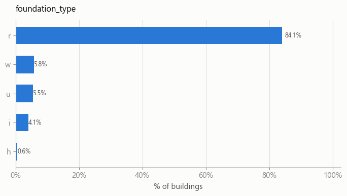

```python
vc = train_values["foundation_type"].value_counts()
pct = vc / vc.sum() * 100
fig, ax = plt.subplots(figsize=(7, 4))
bars = ax.barh(pct.index[::-1], pct.values[::-1], color=CAT["blue"], height=0.6)
ax.set_title("foundation_type", color=INK_PRIMARY, fontsize=12, loc="left", pad=12)
ax.set_xlabel("% of buildings")
ax.xaxis.set_major_formatter(mticker.FuncFormatter(lambda x, _: f"{x:.0f}%"))
for b in bars:
    ax.text(b.get_width() * 1.01, b.get_y() + b.get_height() / 2, f"{b.get_width():.1f}%",
            va="center", ha="left", fontsize=9, color=INK_SECONDARY)
style_ax(ax, hide_spines=("top", "right"))
ax.grid(axis="y", visible=False)
ax.set_xlim(0, pct.values.max() * 1.22)
plt.tight_layout()
plt.savefig(OUT / "categorical_counts_foundation_type.png", dpi=150)
plt.show()
```

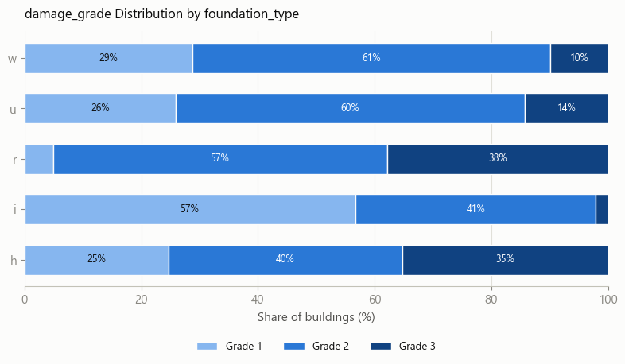

```python
ct = pd.crosstab(df["foundation_type"], df[TARGET_COL], normalize="index").sort_index()
fig, ax = plt.subplots(figsize=(8, 4.8))
left = np.zeros(len(ct))
for grade in [1, 2, 3]:
    vals = ct[grade].values * 100
    ax.barh(ct.index, vals, left=left, color=GRADE_COLORS[grade], height=0.6,
            label=f"Grade {grade}", edgecolor=SURFACE, linewidth=1)
    for y, (l, v) in enumerate(zip(left, vals)):
        if v > 5:
            ax.text(l + v / 2, y, f"{v:.0f}%", ha="center", va="center", fontsize=9,
                    color="white" if grade in (2, 3) else INK_PRIMARY)
    left += vals
ax.set_xlim(0, 100)
ax.set_xlabel("Share of buildings (%)")
ax.set_title("damage_grade Distribution by foundation_type", color=INK_PRIMARY, fontsize=12, loc="left", pad=12)
ax.legend(loc="upper center", bbox_to_anchor=(0.5, -0.18), ncol=3, frameon=False, fontsize=9.5)
style_ax(ax, hide_spines=("top", "right", "left"))
ax.grid(axis="y", visible=False)
plt.tight_layout()
plt.savefig(OUT / "damage_by_foundation.png", dpi=160)
plt.show()
```

**Interpretation:** `foundation_type` is a strong predictor. Foundation type `i` is associated with overwhelmingly low damage (**57% grade 1**, only **2% grade 3**), while `r` -- the most common foundation type by far (**84%** of buildings) -- skews toward the highest damage (**38% grade 3**). This single categorical column carries a lot of the discriminative signal in the dataset.

#### `land_surface_condition`

**Description:** Surface condition of the land where the building was built. *(categorical; possible values: `n`, `o`, `t`)*

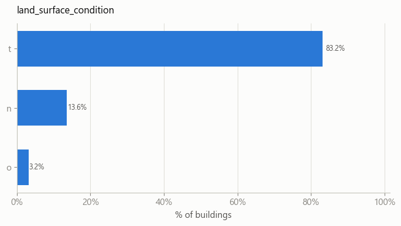

```python
vc = train_values["land_surface_condition"].value_counts()
pct = vc / vc.sum() * 100
fig, ax = plt.subplots(figsize=(7, 4))
bars = ax.barh(pct.index[::-1], pct.values[::-1], color=CAT["blue"], height=0.6)
ax.set_title("land_surface_condition", color=INK_PRIMARY, fontsize=12, loc="left", pad=12)
ax.set_xlabel("% of buildings")
ax.xaxis.set_major_formatter(mticker.FuncFormatter(lambda x, _: f"{x:.0f}%"))
for b in bars:
    ax.text(b.get_width() * 1.01, b.get_y() + b.get_height() / 2, f"{b.get_width():.1f}%",
            va="center", ha="left", fontsize=9, color=INK_SECONDARY)
style_ax(ax, hide_spines=("top", "right"))
ax.grid(axis="y", visible=False)
ax.set_xlim(0, pct.values.max() * 1.22)
plt.tight_layout()
plt.savefig(OUT / "categorical_counts_land_surface_condition.png", dpi=150)
plt.show()
```

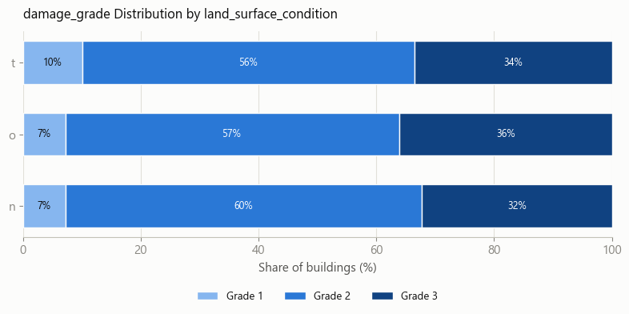

```python
ct_col = pd.crosstab(df["land_surface_condition"], df[TARGET_COL], normalize="index").sort_index()
fig, ax = plt.subplots(figsize=(8, 4.2))
left = np.zeros(len(ct_col))
for grade in [1, 2, 3]:
    vals = ct_col[grade].values * 100
    ax.barh(ct_col.index.astype(str), vals, left=left, color=GRADE_COLORS[grade],
            height=0.6, label=f"Grade {grade}", edgecolor=SURFACE, linewidth=1)
    for y, (l, v) in enumerate(zip(left, vals)):
        if v > 5:
            ax.text(l + v / 2, y, f"{v:.0f}%", ha="center", va="center", fontsize=9,
                    color="white" if grade in (2, 3) else INK_PRIMARY)
    left += vals
ax.set_xlim(0, 100)
ax.set_xlabel("Share of buildings (%)")
ax.set_title("damage_grade Distribution by land_surface_condition", color=INK_PRIMARY, fontsize=12, loc="left", pad=12)
ax.legend(loc="upper center", bbox_to_anchor=(0.5, -0.22), ncol=3, frameon=False, fontsize=9.5)
style_ax(ax, hide_spines=("top", "right", "left"))
ax.grid(axis="y", visible=False)
plt.tight_layout()
plt.savefig(OUT / "damage_by_land_surface_condition.png", dpi=160)
plt.show()
```

#### `roof_type`

**Description:** Type of roof used while building. *(categorical; possible values: `n`, `q`, `x`)*

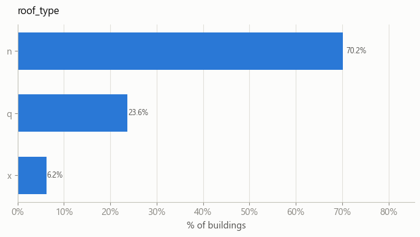

```python
vc = train_values["roof_type"].value_counts()
pct = vc / vc.sum() * 100
fig, ax = plt.subplots(figsize=(7, 4))
bars = ax.barh(pct.index[::-1], pct.values[::-1], color=CAT["blue"], height=0.6)
ax.set_title("roof_type", color=INK_PRIMARY, fontsize=12, loc="left", pad=12)
ax.set_xlabel("% of buildings")
ax.xaxis.set_major_formatter(mticker.FuncFormatter(lambda x, _: f"{x:.0f}%"))
for b in bars:
    ax.text(b.get_width() * 1.01, b.get_y() + b.get_height() / 2, f"{b.get_width():.1f}%",
            va="center", ha="left", fontsize=9, color=INK_SECONDARY)
style_ax(ax, hide_spines=("top", "right"))
ax.grid(axis="y", visible=False)
ax.set_xlim(0, pct.values.max() * 1.22)
plt.tight_layout()
plt.savefig(OUT / "categorical_counts_roof_type.png", dpi=150)
plt.show()
```

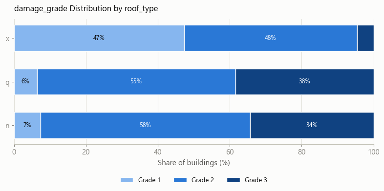

```python
ct_col = pd.crosstab(df["roof_type"], df[TARGET_COL], normalize="index").sort_index()
fig, ax = plt.subplots(figsize=(8, 4.2))
left = np.zeros(len(ct_col))
for grade in [1, 2, 3]:
    vals = ct_col[grade].values * 100
    ax.barh(ct_col.index.astype(str), vals, left=left, color=GRADE_COLORS[grade],
            height=0.6, label=f"Grade {grade}", edgecolor=SURFACE, linewidth=1)
    for y, (l, v) in enumerate(zip(left, vals)):
        if v > 5:
            ax.text(l + v / 2, y, f"{v:.0f}%", ha="center", va="center", fontsize=9,
                    color="white" if grade in (2, 3) else INK_PRIMARY)
    left += vals
ax.set_xlim(0, 100)
ax.set_xlabel("Share of buildings (%)")
ax.set_title("damage_grade Distribution by roof_type", color=INK_PRIMARY, fontsize=12, loc="left", pad=12)
ax.legend(loc="upper center", bbox_to_anchor=(0.5, -0.22), ncol=3, frameon=False, fontsize=9.5)
style_ax(ax, hide_spines=("top", "right", "left"))
ax.grid(axis="y", visible=False)
plt.tight_layout()
plt.savefig(OUT / "damage_by_roof_type.png", dpi=160)
plt.show()
```

**Interpretation:** `roof_type = x` is a strong protective signal -- only 6% of buildings, but 47% of them land in grade 1 and just 5% in grade 3. Compare that to `n` and `q` (94% of buildings combined), where grade 1 is under 8% and grade 3 reaches 34-38%. This is one of the more informative categorical columns in the dataset despite `x`'s low prevalence.

#### `ground_floor_type`

**Description:** Type of the ground floor. *(categorical; possible values: `f`, `m`, `v`, `x`, `z`)*

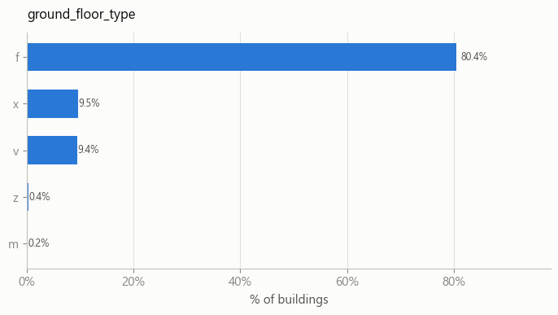

```python
vc = train_values["ground_floor_type"].value_counts()
pct = vc / vc.sum() * 100
fig, ax = plt.subplots(figsize=(7, 4))
bars = ax.barh(pct.index[::-1], pct.values[::-1], color=CAT["blue"], height=0.6)
ax.set_title("ground_floor_type", color=INK_PRIMARY, fontsize=12, loc="left", pad=12)
ax.set_xlabel("% of buildings")
ax.xaxis.set_major_formatter(mticker.FuncFormatter(lambda x, _: f"{x:.0f}%"))
for b in bars:
    ax.text(b.get_width() * 1.01, b.get_y() + b.get_height() / 2, f"{b.get_width():.1f}%",
            va="center", ha="left", fontsize=9, color=INK_SECONDARY)
style_ax(ax, hide_spines=("top", "right"))
ax.grid(axis="y", visible=False)
ax.set_xlim(0, pct.values.max() * 1.22)
plt.tight_layout()
plt.savefig(OUT / "categorical_counts_ground_floor_type.png", dpi=150)
plt.show()
```

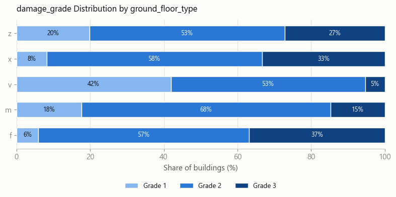

```python
ct_col = pd.crosstab(df["ground_floor_type"], df[TARGET_COL], normalize="index").sort_index()
fig, ax = plt.subplots(figsize=(8, 4.2))
left = np.zeros(len(ct_col))
for grade in [1, 2, 3]:
    vals = ct_col[grade].values * 100
    ax.barh(ct_col.index.astype(str), vals, left=left, color=GRADE_COLORS[grade],
            height=0.6, label=f"Grade {grade}", edgecolor=SURFACE, linewidth=1)
    for y, (l, v) in enumerate(zip(left, vals)):
        if v > 5:
            ax.text(l + v / 2, y, f"{v:.0f}%", ha="center", va="center", fontsize=9,
                    color="white" if grade in (2, 3) else INK_PRIMARY)
    left += vals
ax.set_xlim(0, 100)
ax.set_xlabel("Share of buildings (%)")
ax.set_title("damage_grade Distribution by ground_floor_type", color=INK_PRIMARY, fontsize=12, loc="left", pad=12)
ax.legend(loc="upper center", bbox_to_anchor=(0.5, -0.22), ncol=3, frameon=False, fontsize=9.5)
style_ax(ax, hide_spines=("top", "right", "left"))
ax.grid(axis="y", visible=False)
plt.tight_layout()
plt.savefig(OUT / "damage_by_ground_floor_type.png", dpi=160)
plt.show()
```

**Interpretation:** `ground_floor_type = v` stands out as protective (42% grade 1, only 5% grade 3) versus the dominant `f` (80% of buildings: 6% grade 1, 37% grade 3). The rare `z` and `m` categories also skew safer than `f`. Ground-floor construction material is a meaningful damage driver, similar in shape to `foundation_type`.

#### `other_floor_type`

**Description:** Type of construction used in floors higher than the ground floor (excluding roof). *(categorical; possible values: `j`, `q`, `s`, `x`)*

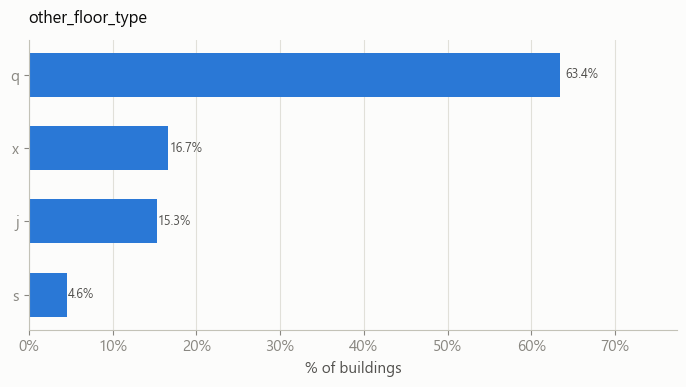

```python
vc = train_values["other_floor_type"].value_counts()
pct = vc / vc.sum() * 100
fig, ax = plt.subplots(figsize=(7, 4))
bars = ax.barh(pct.index[::-1], pct.values[::-1], color=CAT["blue"], height=0.6)
ax.set_title("other_floor_type", color=INK_PRIMARY, fontsize=12, loc="left", pad=12)
ax.set_xlabel("% of buildings")
ax.xaxis.set_major_formatter(mticker.FuncFormatter(lambda x, _: f"{x:.0f}%"))
for b in bars:
    ax.text(b.get_width() * 1.01, b.get_y() + b.get_height() / 2, f"{b.get_width():.1f}%",
            va="center", ha="left", fontsize=9, color=INK_SECONDARY)
style_ax(ax, hide_spines=("top", "right"))
ax.grid(axis="y", visible=False)
ax.set_xlim(0, pct.values.max() * 1.22)
plt.tight_layout()
plt.savefig(OUT / "categorical_counts_other_floor_type.png", dpi=150)
plt.show()
```

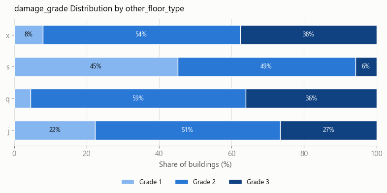

```python
ct_col = pd.crosstab(df["other_floor_type"], df[TARGET_COL], normalize="index").sort_index()
fig, ax = plt.subplots(figsize=(8, 4.2))
left = np.zeros(len(ct_col))
for grade in [1, 2, 3]:
    vals = ct_col[grade].values * 100
    ax.barh(ct_col.index.astype(str), vals, left=left, color=GRADE_COLORS[grade],
            height=0.6, label=f"Grade {grade}", edgecolor=SURFACE, linewidth=1)
    for y, (l, v) in enumerate(zip(left, vals)):
        if v > 5:
            ax.text(l + v / 2, y, f"{v:.0f}%", ha="center", va="center", fontsize=9,
                    color="white" if grade in (2, 3) else INK_PRIMARY)
    left += vals
ax.set_xlim(0, 100)
ax.set_xlabel("Share of buildings (%)")
ax.set_title("damage_grade Distribution by other_floor_type", color=INK_PRIMARY, fontsize=12, loc="left", pad=12)
ax.legend(loc="upper center", bbox_to_anchor=(0.5, -0.22), ncol=3, frameon=False, fontsize=9.5)
style_ax(ax, hide_spines=("top", "right", "left"))
ax.grid(axis="y", visible=False)
plt.tight_layout()
plt.savefig(OUT / "damage_by_other_floor_type.png", dpi=160)
plt.show()
```

**Interpretation:** `other_floor_type = s` is the strongest protective category found among the remaining categoricals (45% grade 1, only 6% grade 3), while `q` -- the most common value at 63% of buildings -- skews toward more damage (36% grade 3). `j` sits in between. This column carries real, usable signal.

#### `position`

**Description:** Position of the building. *(categorical; possible values: `j`, `o`, `s`, `t`)*

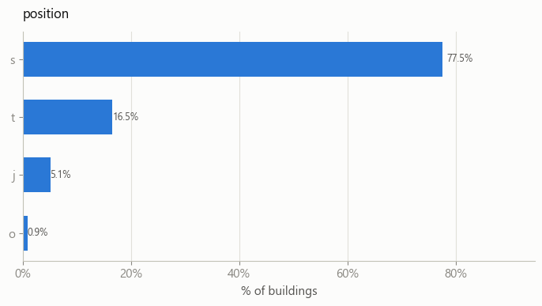

```python
vc = train_values["position"].value_counts()
pct = vc / vc.sum() * 100
fig, ax = plt.subplots(figsize=(7, 4))
bars = ax.barh(pct.index[::-1], pct.values[::-1], color=CAT["blue"], height=0.6)
ax.set_title("position", color=INK_PRIMARY, fontsize=12, loc="left", pad=12)
ax.set_xlabel("% of buildings")
ax.xaxis.set_major_formatter(mticker.FuncFormatter(lambda x, _: f"{x:.0f}%"))
for b in bars:
    ax.text(b.get_width() * 1.01, b.get_y() + b.get_height() / 2, f"{b.get_width():.1f}%",
            va="center", ha="left", fontsize=9, color=INK_SECONDARY)
style_ax(ax, hide_spines=("top", "right"))
ax.grid(axis="y", visible=False)
ax.set_xlim(0, pct.values.max() * 1.22)
plt.tight_layout()
plt.savefig(OUT / "categorical_counts_position.png", dpi=150)
plt.show()
```

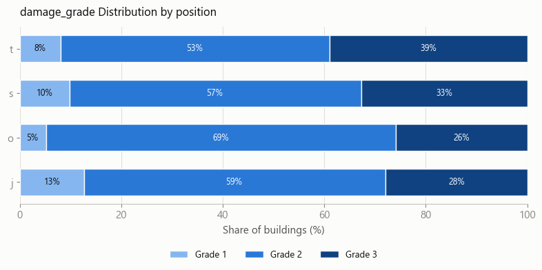

```python
ct_col = pd.crosstab(df["position"], df[TARGET_COL], normalize="index").sort_index()
fig, ax = plt.subplots(figsize=(8, 4.2))
left = np.zeros(len(ct_col))
for grade in [1, 2, 3]:
    vals = ct_col[grade].values * 100
    ax.barh(ct_col.index.astype(str), vals, left=left, color=GRADE_COLORS[grade],
            height=0.6, label=f"Grade {grade}", edgecolor=SURFACE, linewidth=1)
    for y, (l, v) in enumerate(zip(left, vals)):
        if v > 5:
            ax.text(l + v / 2, y, f"{v:.0f}%", ha="center", va="center", fontsize=9,
                    color="white" if grade in (2, 3) else INK_PRIMARY)
    left += vals
ax.set_xlim(0, 100)
ax.set_xlabel("Share of buildings (%)")
ax.set_title("damage_grade Distribution by position", color=INK_PRIMARY, fontsize=12, loc="left", pad=12)
ax.legend(loc="upper center", bbox_to_anchor=(0.5, -0.22), ncol=3, frameon=False, fontsize=9.5)
style_ax(ax, hide_spines=("top", "right", "left"))
ax.grid(axis="y", visible=False)
plt.tight_layout()
plt.savefig(OUT / "damage_by_position.png", dpi=160)
plt.show()
```

**Interpretation:** `position` shows a modest but real split -- `t` has the highest grade-3 share (39%), while `o` skews toward grade 2 (69%) with a lower grade-3 share (26%). The effect size is smaller than for the roof- or floor-type columns but still worth keeping.

#### `plan_configuration`

**Description:** Building plan configuration. *(categorical; possible values: `a`, `c`, `d`, `f`, `m`, `n`, `o`, `q`, `s`, `u`)*

[output not shown]

[figure not shown]

```python
vc = train_values["plan_configuration"].value_counts()
pct = vc / vc.sum() * 100
fig, ax = plt.subplots(figsize=(7, 4))
bars = ax.barh(pct.index[::-1], pct.values[::-1], color=CAT["blue"], height=0.6)
ax.set_title("plan_configuration", color=INK_PRIMARY, fontsize=12, loc="left", pad=12)
ax.set_xlabel("% of buildings")
ax.xaxis.set_major_formatter(mticker.FuncFormatter(lambda x, _: f"{x:.0f}%"))
for b, count in zip(bars, vc.values[::-1]):
    ax.text(b.get_width() * 1.01, b.get_y() + b.get_height() / 2, f"{b.get_width():.2f}% ",
            va="center", ha="left", fontsize=9, color=INK_SECONDARY)
style_ax(ax, hide_spines=("top", "right"))
ax.grid(axis="y", visible=False)
ax.set_xlim(0, pct.values.max() * 1.22)
plt.tight_layout()
plt.savefig(OUT / "categorical_counts_plan_configuration.png", dpi=150)
plt.show()
```

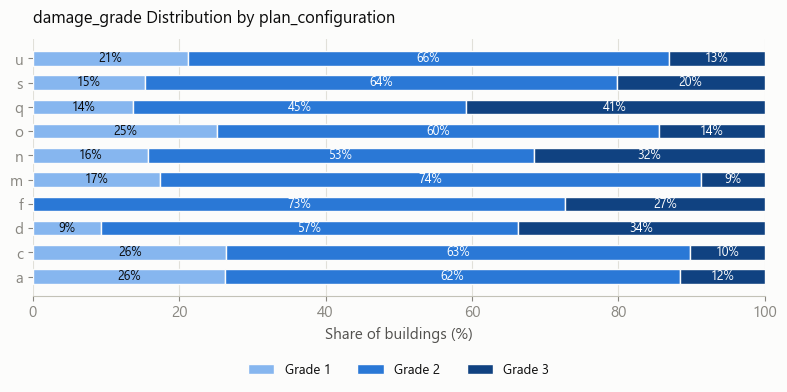

```python
ct_col = pd.crosstab(df["plan_configuration"], df[TARGET_COL], normalize="index").sort_index()
fig, ax = plt.subplots(figsize=(8, 4.2))
left = np.zeros(len(ct_col))
for grade in [1, 2, 3]:
    vals = ct_col[grade].values * 100
    ax.barh(ct_col.index.astype(str), vals, left=left, color=GRADE_COLORS[grade],
            height=0.6, label=f"Grade {grade}", edgecolor=SURFACE, linewidth=1)
    for y, (l, v) in enumerate(zip(left, vals)):
        if v > 5:
            ax.text(l + v / 2, y, f"{v:.0f}%", ha="center", va="center", fontsize=9,
                    color="white" if grade in (2, 3) else INK_PRIMARY)
    left += vals
ax.set_xlim(0, 100)
ax.set_xlabel("Share of buildings (%)")
ax.set_title("damage_grade Distribution by plan_configuration", color=INK_PRIMARY, fontsize=12, loc="left", pad=12)
ax.legend(loc="upper center", bbox_to_anchor=(0.5, -0.22), ncol=3, frameon=False, fontsize=9.5)
style_ax(ax, hide_spines=("top", "right", "left"))
ax.grid(axis="y", visible=False)
plt.tight_layout()
plt.savefig(OUT / "damage_by_plan_configuration.png", dpi=160)
plt.show()
```

**Interpretation:** `plan_configuration` is dominated by `d` (96% of buildings, tracking the overall population split almost exactly), but the minority configurations spread widely: `q` (2% of buildings) is the worst category (41% grade 3), while `c`, `a`, `m`, `o`, and `u` are all noticeably safer (grade-3 share of 9-15%). The signal is concentrated in the rare categories, echoing the Section 7 finding that this column's discriminative power lives in its minority levels.

#### `legal_ownership_status`

**Description:** Legal ownership status of the land where the building was built. *(categorical; possible values: `a`, `r`, `v`, `w`)*

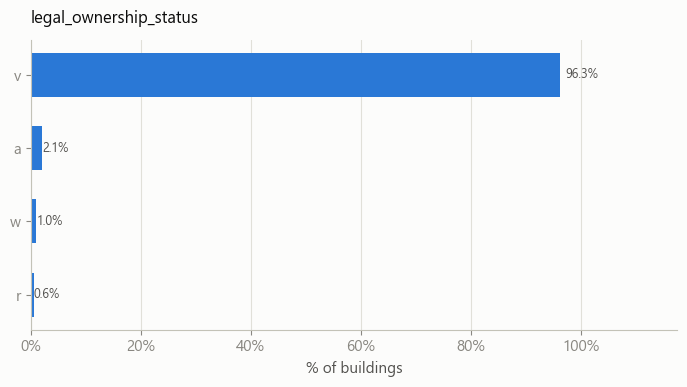

```python
vc = train_values["legal_ownership_status"].value_counts()
pct = vc / vc.sum() * 100
fig, ax = plt.subplots(figsize=(7, 4))
bars = ax.barh(pct.index[::-1], pct.values[::-1], color=CAT["blue"], height=0.6)
ax.set_title("legal_ownership_status", color=INK_PRIMARY, fontsize=12, loc="left", pad=12)
ax.set_xlabel("% of buildings")
ax.xaxis.set_major_formatter(mticker.FuncFormatter(lambda x, _: f"{x:.0f}%"))
for b in bars:
    ax.text(b.get_width() * 1.01, b.get_y() + b.get_height() / 2, f"{b.get_width():.1f}%",
            va="center", ha="left", fontsize=9, color=INK_SECONDARY)
style_ax(ax, hide_spines=("top", "right"))
ax.grid(axis="y", visible=False)
ax.set_xlim(0, pct.values.max() * 1.22)
plt.tight_layout()
plt.savefig(OUT / "categorical_counts_legal_ownership_status.png", dpi=150)
plt.show()
```

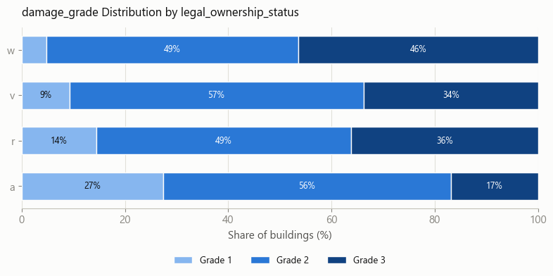

```python
ct_col = pd.crosstab(df["legal_ownership_status"], df[TARGET_COL], normalize="index").sort_index()
fig, ax = plt.subplots(figsize=(8, 4.2))
left = np.zeros(len(ct_col))
for grade in [1, 2, 3]:
    vals = ct_col[grade].values * 100
    ax.barh(ct_col.index.astype(str), vals, left=left, color=GRADE_COLORS[grade],
            height=0.6, label=f"Grade {grade}", edgecolor=SURFACE, linewidth=1)
    for y, (l, v) in enumerate(zip(left, vals)):
        if v > 5:
            ax.text(l + v / 2, y, f"{v:.0f}%", ha="center", va="center", fontsize=9,
                    color="white" if grade in (2, 3) else INK_PRIMARY)
    left += vals
ax.set_xlim(0, 100)
ax.set_xlabel("Share of buildings (%)")
ax.set_title("damage_grade Distribution by legal_ownership_status", color=INK_PRIMARY, fontsize=12, loc="left", pad=12)
ax.legend(loc="upper center", bbox_to_anchor=(0.5, -0.22), ncol=3, frameon=False, fontsize=9.5)
style_ax(ax, hide_spines=("top", "right", "left"))
ax.grid(axis="y", visible=False)
plt.tight_layout()
plt.savefig(OUT / "damage_by_legal_ownership_status.png", dpi=160)
plt.show()
```

**Interpretation:** Among the minority ownership categories, `a` is notably protective (27% grade 1, only 17% grade 3), while `w` is the most damaging of any category in this column (46% grade 3). `v`, the dominant category (96% of buildings), tracks the overall population split. Ownership status correlates with damage, plausibly as a proxy for building type or maintenance investment.

#### Section 8: Binary flag features

```python
print_header("8. BINARY FLAG FEATURES")

print("--- Superstructure flags: prevalence (mean) ---")

display(
    train_values[SUPERSTRUCTURE_COLS]
    .mean()
    .sort_values(ascending=False)
)

n_flags_per_building = (
    train_values[SUPERSTRUCTURE_COLS]
    .sum(axis=1)
)

print("\n--- Number of superstructure flags set per building ---")

display(
    n_flags_per_building
    .value_counts()
    .sort_index()
)

print("\n--- Secondary-use flags: prevalence (mean) ---")

display(
    train_values[SECONDARY_USE_COLS]
    .mean()
    .sort_values(ascending=False)
)

computed_umbrella = (
    train_values[SECONDARY_USE_SUB_COLS]
    .sum(axis=1) > 0
).astype(int)

mismatches = int(
    (
        computed_umbrella !=
        train_values[SECONDARY_USE_UMBRELLA_COL]
    ).sum()
)

print(
    f"\nConsistency check: mismatches between "
    f"'{SECONDARY_USE_UMBRELLA_COL}' and OR of "
    f"its sub-flags: {mismatches}"
)
```

```
================================================================================
8. BINARY FLAG FEATURES
================================================================================
--- Superstructure flags: prevalence (mean) ---
```

```
has_superstructure_mud_mortar_stone       0.761935
has_superstructure_timber                 0.254988
has_superstructure_adobe_mud              0.088645
has_superstructure_bamboo                 0.085011
has_superstructure_cement_mortar_brick    0.075268
has_superstructure_mud_mortar_brick       0.068154
has_superstructure_rc_non_engineered      0.042590
has_superstructure_stone_flag             0.034332
has_superstructure_cement_mortar_stone    0.018235
has_superstructure_rc_engineered          0.015859
has_superstructure_other                  0.014985
dtype: float64
```

```
--- Number of superstructure flags set per building ---
```

```
1    176016
2     57838
3     20210
4      4925
5      1259
6       314
7        35
8         4
Name: count, dtype: int64
```

```
--- Secondary-use flags: prevalence (mean) ---
```

```
has_secondary_use                0.111880
has_secondary_use_agriculture    0.064378
has_secondary_use_hotel          0.033626
has_secondary_use_rental         0.008101
has_secondary_use_other          0.005119
has_secondary_use_industry       0.001071
has_secondary_use_institution    0.000940
has_secondary_use_school         0.000361
has_secondary_use_health_post    0.000188
has_secondary_use_gov_office     0.000146
has_secondary_use_use_police     0.000088
dtype: float64
```

```
Consistency check: mismatches between 'has_secondary_use' and OR of its sub-flags: 0
```

#### Plot: binary flag prevalence

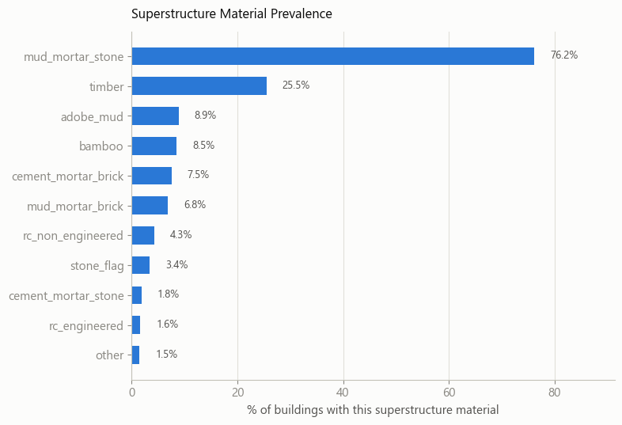

```python
prev = train_values[SUPERSTRUCTURE_COLS].mean().sort_values(ascending=True) * 100
short_labels = [c.replace("has_superstructure_", "") for c in prev.index]
fig, ax = plt.subplots(figsize=(8, 5.5))
bars = ax.barh(short_labels, prev.values, color=CAT["blue"], height=0.6)
bar_labels(ax, bars, fmt="{:.1f}%", horizontal=True)
ax.set_xlabel("% of buildings with this superstructure material")
ax.set_title("Superstructure Material Prevalence", color=INK_PRIMARY, fontsize=12, loc="left", pad=12)
ax.set_xlim(0, prev.max() * 1.2)
style_ax(ax, hide_spines=("top", "right"))
ax.grid(axis="y", visible=False)
plt.tight_layout()
plt.savefig(OUT / "superstructure_prevalence.png", dpi=160)
plt.show()
```

**Interpretation:** Superstructure material is heavily skewed toward **mud mortar stone**, present in **76.2%** of buildings -- by far the dominant construction type. **Timber** is a distant second at **25.5%**, and every other material (adobe mud, bamboo, cement mortar brick, mud mortar brick, RC non-engineered, stone flag, cement mortar stone, RC engineered, other) appears in under 9% of buildings each. Engineered construction is rare: **RC engineered** appears in only **1.6%** of buildings, meaning the vast majority of the housing stock relies on non-engineered, load-bearing masonry or timber construction.

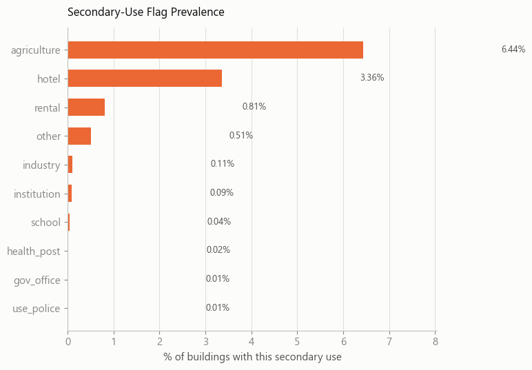

```python
prev2 = train_values[SECONDARY_USE_SUB_COLS].mean().sort_values(ascending=True) * 100
short_labels2 = [c.replace("has_secondary_use_", "") for c in prev2.index]
fig, ax = plt.subplots(figsize=(8, 5.5))
bars = ax.barh(short_labels2, prev2.values, color=CAT["orange"], height=0.6)
bar_labels(ax, bars, fmt="{:.2f}%", horizontal=True)
ax.set_xlabel("% of buildings with this secondary use")
ax.set_title("Secondary-Use Flag Prevalence", color=INK_PRIMARY, fontsize=12, loc="left", pad=12)
ax.set_xlim(0, prev2.max() * 1.25)
style_ax(ax, hide_spines=("top", "right"))
ax.grid(axis="y", visible=False)
plt.tight_layout()
plt.savefig(OUT / "secondary_use_prevalence.png", dpi=160)
plt.show()
```

**Interpretation:** Secondary use of buildings is rare overall -- only **11.2%** of buildings have any secondary use (`has_secondary_use`), and within that minority the usage is dominated by two categories: **agriculture (6.4%)** and **hotel (3.4%)**. Every other sub-flag (rental, other, industry, institution, school, health post, gov office, police) affects **under 1%** of buildings, with several (school, health post, gov office, police) present in fewer than 0.1% -- only a few dozen buildings each.

These extremely rare sub-flags carry almost no statistical weight individually and are unlikely to be useful predictors on their own, though grouping them into the broader `has_secondary_use` umbrella (already validated as 100% consistent with the OR of its sub-flags) is a more robust way to capture the signal than relying on the sparsest categories individually.

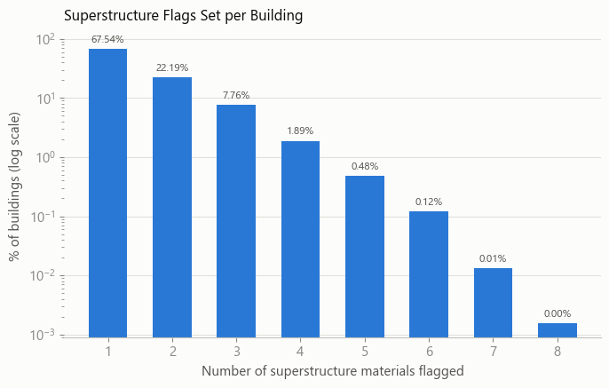

```python
n_flags = n_flags_per_building.value_counts().sort_index()
pct = n_flags / n_flags.sum() * 100
fig, ax = plt.subplots(figsize=(7, 4.5))
bars = ax.bar(pct.index.astype(str), pct.values, color=CAT["blue"], width=0.6)
ax.set_yscale("log")
for b, v in zip(bars, pct.values):
    ax.text(b.get_x() + b.get_width() / 2, b.get_height() * 1.15, f"{v:.2f}%",
            ha="center", va="bottom", fontsize=8.5, color=INK_SECONDARY)
ax.set_xlabel("Number of superstructure materials flagged")
ax.set_ylabel("% of buildings (log scale)")
ax.set_title("Superstructure Flags Set per Building", color=INK_PRIMARY, fontsize=12, loc="left", pad=12)
style_ax(ax)
ax.grid(axis="x", visible=False)
plt.tight_layout()
plt.savefig(OUT / "flags_per_building.png", dpi=160)
plt.show()
```

This is consistent with the prevalence chart above: a typical building is built almost entirely from one dominant material (usually mud mortar stone) with at most one secondary material (e.g. a timber roof structure on a stone wall). Buildings flagged with many materials at once are true outliers and likely reflect additions, renovations, or mixed-construction structures rather than a distinct population worth modeling separately.

#### Section 9: Bivariate Signal Check -- Geography, Numeric & Superstructure Features

```python
print_header("9. FEATURE RELATIONSHIPS WITH TARGET")

print(
    "--- damage_grade distribution by "
    "foundation_type (row %) ---"
)

display(
    pd.crosstab(
        df["foundation_type"],
        df[TARGET_COL],
        normalize="index"
    ).round(3)
)

print(
    "\n--- damage_grade distribution by "
    "geo_level_1_id (row %, first 8 shown) ---"
)

display(
    pd.crosstab(
        df["geo_level_1_id"],
        df[TARGET_COL],
        normalize="index"
    )
    .round(3)
    .head(8)
)

print(
    "\n--- Pearson correlation of numeric "
    "features with damage_grade ---"
)

display(
    df[NUMERIC_COLS + [TARGET_COL]]
    .corr()[TARGET_COL]
    .sort_values(ascending=False)
)
```

```
================================================================================
9. FEATURE RELATIONSHIPS WITH TARGET
================================================================================
--- damage_grade distribution by foundation_type (row %) ---
```

| damage_grade foundation_type | 1 | 2 | 3 |
| --- | --- | --- | --- |
| h | 0.247 | 0.400 | 0.353 |
| i | 0.568 | 0.412 | 0.021 |
| r | 0.049 | 0.573 | 0.378 |
| u | 0.259 | 0.599 | 0.142 |
| w | 0.288 | 0.613 | 0.099 |

```
--- damage_grade distribution by geo_level_1_id (row %, first 8 shown) ---
```

| damage_grade geo_level_1_id | 1 | 2 | 3 |
| --- | --- | --- | --- |
| 0 | 0.084 | 0.767 | 0.149 |
| 1 | 0.152 | 0.735 | 0.113 |
| 2 | 0.091 | 0.655 | 0.253 |
| 3 | 0.032 | 0.603 | 0.364 |
| 4 | 0.036 | 0.766 | 0.198 |
| 5 | 0.166 | 0.749 | 0.086 |
| 6 | 0.086 | 0.665 | 0.248 |
| 7 | 0.054 | 0.594 | 0.352 |

```
--- Pearson correlation of numeric features with damage_grade ---
```

```
damage_grade           1.000000
count_floors_pre_eq    0.122308
count_families         0.056151
height_percentage      0.048130
geo_level_2_id         0.043161
age                    0.029273
geo_level_3_id         0.007932
geo_level_1_id        -0.072347
area_percentage       -0.125221
Name: damage_grade, dtype: float64
```

#### `geo_level_1_id`

**Description:** Geographic region in which the building exists, from largest (level 1) to most specific sub-region (level 3) -- `geo_level_1_id` is the top-level (broadest) region identifier. *(int; possible values: 0-30)*

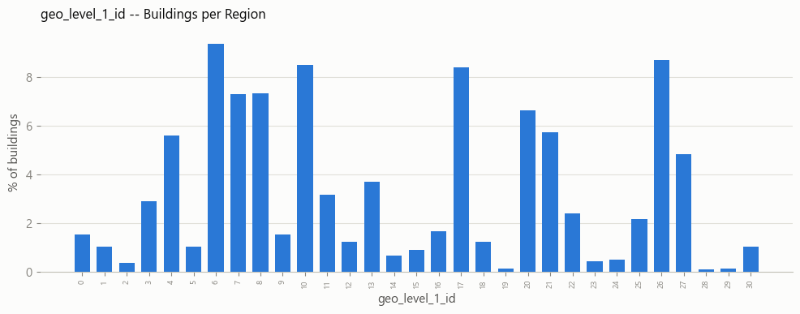

```python
vc = train_values["geo_level_1_id"].value_counts().sort_index()
pct = vc / vc.sum() * 100
fig, ax = plt.subplots(figsize=(10, 4))
ax.bar(pct.index.astype(str), pct.values, color=CAT["blue"], width=0.7)
ax.set_title("geo_level_1_id -- Buildings per Region", color=INK_PRIMARY, fontsize=12, loc="left", pad=12)
ax.set_xlabel("geo_level_1_id")
ax.set_ylabel("% of buildings")
ax.tick_params(axis="x", labelsize=7, rotation=90)
style_ax(ax)
ax.grid(axis="x", visible=False)
plt.tight_layout()
plt.savefig(OUT / "value_counts_geo_level_1_id.png", dpi=150)
plt.show()
```

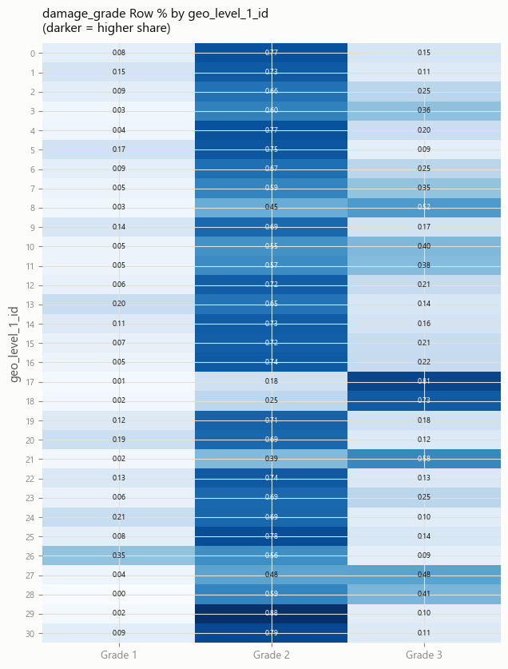

```python
ct_geo = pd.crosstab(df["geo_level_1_id"], df[TARGET_COL], normalize="index").sort_index()
fig, ax = plt.subplots(figsize=(6.5, 8.5))
ax.imshow(ct_geo.values, aspect="auto", cmap="Blues", vmin=0, vmax=ct_geo.values.max())
ax.set_yticks(range(len(ct_geo.index)))
ax.set_yticklabels(ct_geo.index, fontsize=8)
ax.set_xticks(range(3))
ax.set_xticklabels(["Grade 1", "Grade 2", "Grade 3"], fontsize=9.5)
ax.set_ylabel("geo_level_1_id")
ax.set_title("damage_grade Row % by geo_level_1_id\n(darker = higher share)", color=INK_PRIMARY, fontsize=11.5, loc="left", pad=10)
for i in range(ct_geo.shape[0]):
    for j in range(ct_geo.shape[1]):
        v = ct_geo.values[i, j]
        ax.text(j, i, f"{v:.2f}", ha="center", va="center", fontsize=6.7,
                color="white" if v > 0.5 else INK_PRIMARY)
for s in ax.spines.values():
    s.set_visible(False)
plt.tight_layout()
plt.savefig(OUT / "damage_by_geo1.png", dpi=160)
plt.show()
```

**Interpretation:** Location matters. Damage-grade distribution varies substantially by `geo_level_1_id` (e.g. `geo_level_1_id` value 3 sees **36%** grade-3 damage vs. value 5 at only **9%**), consistent with real seismic intensity varying geographically -- this justifies the effort put into target-encoding the geo hierarchy rather than discarding it.

#### Relation between Numeric Features and Damage grade

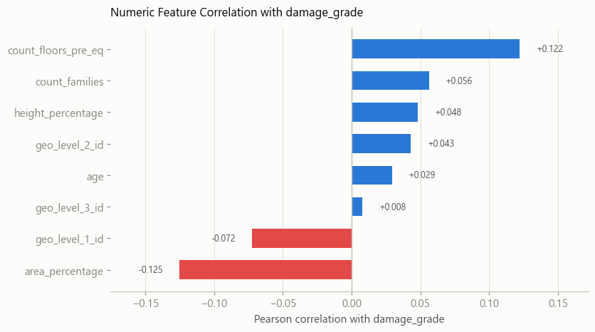

```python
corr = df[NUMERIC_COLS + [TARGET_COL]].corr()[TARGET_COL].drop(TARGET_COL).sort_values()
colors_corr = [DIVERGE_RED if v < 0 else DIVERGE_BLUE for v in corr.values]
fig, ax = plt.subplots(figsize=(8.5, 4.8))
bars = ax.barh(corr.index, corr.values, color=colors_corr, height=0.6)
pad = 0.012
for b, v in zip(bars, corr.values):
    ax.text(v + (pad if v >= 0 else -pad), b.get_y() + b.get_height() / 2, f"{v:+.3f}",
            va="center", ha="left" if v >= 0 else "right", fontsize=9, color=INK_SECONDARY)
ax.axvline(0, color=BASELINE, linewidth=1)
ax.set_xlim(corr.min() - 0.05, corr.max() + 0.05)
ax.set_xlabel("Pearson correlation with damage_grade")
ax.set_title("Numeric Feature Correlation with damage_grade", color=INK_PRIMARY, fontsize=12, loc="left", pad=12)
style_ax(ax, hide_spines=("top", "right", "left"))
ax.grid(axis="y", visible=False)
plt.tight_layout()
plt.savefig(OUT / "correlation_with_target.png", dpi=160)
plt.show()
```

**Interpretation:**

- **Linear correlations with numeric features are all weak** (|r| <= 0.13). This tells us the relationship between numeric features and damage is likely **non-linear and/or interaction-driven** rather than simple monotonic trends -- an argument for using tree-based models (which capture interactions and non-linearities natively) over plain linear models.
- More floors (`count_floors_pre_eq`) is mildly associated with *more* damage, while larger footprint (`area_percentage`) is mildly associated with *less* damage -- plausible physically (taller/narrower buildings are more vulnerable to shaking; wider, larger-footprint construction may be structurally different, e.g. more likely to be modern/well-built).

#### `count_floors_pre_eq`

**Description:** Number of floors in the building before the earthquake. *(int)*

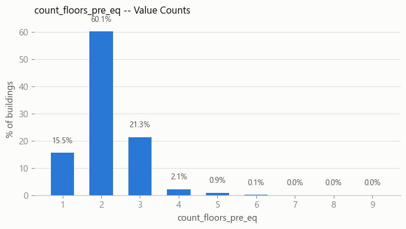

```python
vc = train_values["count_floors_pre_eq"].value_counts().sort_index()
pct = vc / vc.sum() * 100
fig, ax = plt.subplots(figsize=(7, 4))
bars = ax.bar(pct.index.astype(str), pct.values, color=CAT["blue"], width=0.6)
bar_labels(ax, bars, fmt="{:.1f}%")
ax.set_title("count_floors_pre_eq -- Value Counts", color=INK_PRIMARY, fontsize=12, loc="left", pad=12)
ax.set_xlabel("count_floors_pre_eq")
ax.set_ylabel("% of buildings")
style_ax(ax)
ax.grid(axis="x", visible=False)
plt.tight_layout()
plt.savefig(OUT / "value_counts_count_floors_pre_eq.png", dpi=150)
plt.show()
```

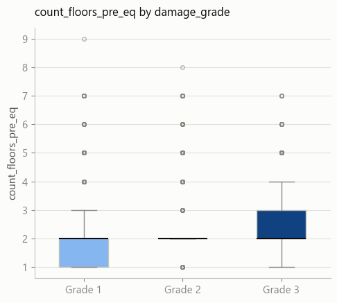

```python
data_by_grade = [df.loc[df[TARGET_COL] == g, "count_floors_pre_eq"].values for g in [1, 2, 3]]
fig, ax = plt.subplots(figsize=(5, 4.5))
bp = ax.boxplot(data_by_grade, vert=True, widths=0.5, patch_artist=True, showfliers=True,
                 flierprops=dict(marker="o", markersize=4, markerfacecolor="none", markeredgecolor=INK_MUTED, alpha=0.6),
                 medianprops=dict(color=INK_PRIMARY, linewidth=1.5),
                 whiskerprops=dict(color=INK_MUTED),
                 capprops=dict(color=INK_MUTED))
for patch, grade in zip(bp["boxes"], [1, 2, 3]):
    patch.set_facecolor(GRADE_COLORS[grade])
    patch.set_edgecolor(BASELINE)
ax.set_xticks([1, 2, 3])
ax.set_xticklabels(["Grade 1", "Grade 2", "Grade 3"])
ax.set_ylabel("count_floors_pre_eq")
ax.set_title("count_floors_pre_eq by damage_grade", color=INK_PRIMARY, fontsize=12, loc="left", pad=12)
style_ax(ax, hide_spines=("top", "right"))
ax.grid(axis="x", visible=False)
plt.tight_layout()
plt.savefig(OUT / "damage_by_count_floors_pre_eq_box.png", dpi=160)
plt.show()
```

**Interpretation:** Median floor count is 2 across all three grades, but the distribution shifts upward with severity -- grade 1 buildings are more often 1-floor (mean 1.84), while grade 3 buildings more often reach 3 floors (mean 2.21, IQR up to 3). Taller buildings are consistently associated with more damage, matching the mildly positive Pearson correlation (+0.122) computed earlier.

#### `age`

**Description:** Age of the building in years. *(int)*

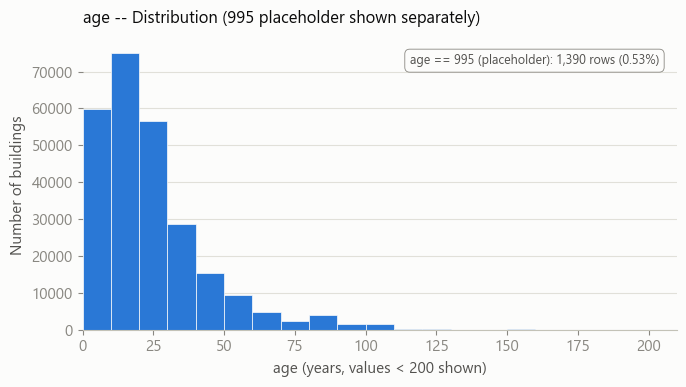

```python
age_vals = train_values["age"]
fig, ax = plt.subplots(figsize=(7, 4))
ax.hist(age_vals[age_vals < 200], bins=range(0, 205, 10), color=CAT["blue"], edgecolor=SURFACE, linewidth=0.5)
ax.set_xlim(0, 210)
n995 = int((age_vals == 995).sum())
pct995 = n995 / len(age_vals) * 100
ax.text(0.97, 0.95, f"age == 995 (placeholder): {n995:,} rows ({pct995:.2f}%)",
        transform=ax.transAxes, ha="right", va="top", fontsize=9, color=INK_SECONDARY,
        bbox=dict(boxstyle="round,pad=0.4", facecolor=SURFACE, edgecolor=INK_MUTED, linewidth=0.6))
ax.set_title("age -- Distribution (995 placeholder shown separately)", color=INK_PRIMARY, fontsize=12, loc="left", pad=12)
ax.set_xlabel("age (years, values < 200 shown)")
ax.set_ylabel("Number of buildings")
style_ax(ax)
ax.grid(axis="x", visible=False)
plt.tight_layout()
plt.savefig(OUT / "value_counts_age.png", dpi=150)
plt.show()
```

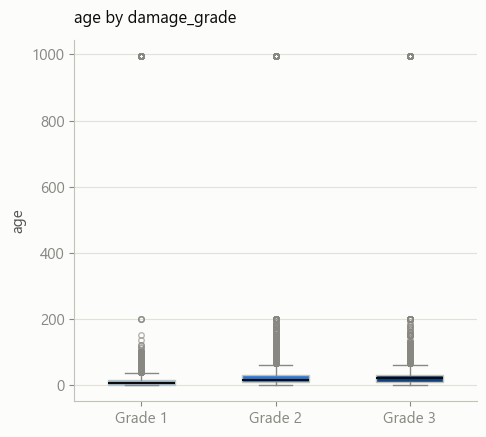

```python
data_by_grade = [df.loc[df[TARGET_COL] == g, "age"].values for g in [1, 2, 3]]
fig, ax = plt.subplots(figsize=(5, 4.5))
bp = ax.boxplot(data_by_grade, vert=True, widths=0.5, patch_artist=True, showfliers=True,
                 flierprops=dict(marker="o", markersize=4, markerfacecolor="none", markeredgecolor=INK_MUTED, alpha=0.6),
                 medianprops=dict(color=INK_PRIMARY, linewidth=1.5),
                 whiskerprops=dict(color=INK_MUTED),
                 capprops=dict(color=INK_MUTED))
for patch, grade in zip(bp["boxes"], [1, 2, 3]):
    patch.set_facecolor(GRADE_COLORS[grade])
    patch.set_edgecolor(BASELINE)
ax.set_xticks([1, 2, 3])
ax.set_xticklabels(["Grade 1", "Grade 2", "Grade 3"])
ax.set_ylabel("age")
ax.set_title("age by damage_grade", color=INK_PRIMARY, fontsize=12, loc="left", pad=12)
style_ax(ax, hide_spines=("top", "right"))
ax.grid(axis="x", visible=False)
plt.tight_layout()
plt.savefig(OUT / "damage_by_age_box.png", dpi=160)
plt.show()
```

**Interpretation:** Grade 1 buildings skew much newer (median age 5 years) than grade 2 and grade 3 (median 15 and 20 years respectively, with a similar overall spread). Older buildings are more likely to sustain heavier damage, consistent with age-related degradation of construction materials and older buildings predating modern building codes.

#### `area_percentage`

**Description:** Normalized area of the building footprint. *(int)*

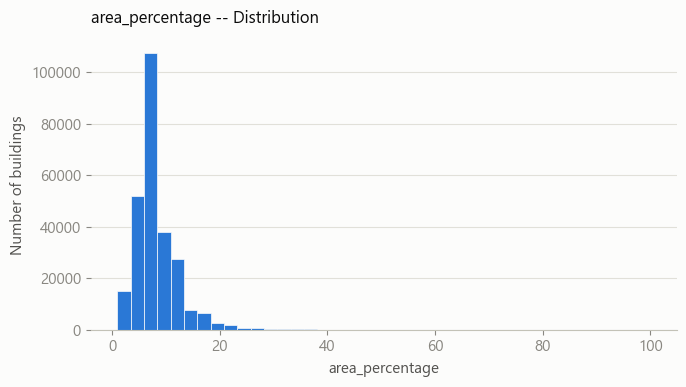

```python
fig, ax = plt.subplots(figsize=(7, 4))
ax.hist(train_values["area_percentage"], bins=40, color=CAT["blue"], edgecolor=SURFACE, linewidth=0.5)
ax.set_title("area_percentage -- Distribution", color=INK_PRIMARY, fontsize=12, loc="left", pad=12)
ax.set_xlabel("area_percentage")
ax.set_ylabel("Number of buildings")
style_ax(ax)
ax.grid(axis="x", visible=False)
plt.tight_layout()
plt.savefig(OUT / "value_counts_area_percentage.png", dpi=150)
plt.show()
```

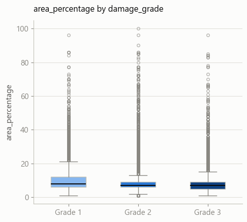

```python
data_by_grade = [df.loc[df[TARGET_COL] == g, "area_percentage"].values for g in [1, 2, 3]]
fig, ax = plt.subplots(figsize=(5, 4.5))
bp = ax.boxplot(data_by_grade, vert=True, widths=0.5, patch_artist=True, showfliers=True,
                 flierprops=dict(marker="o", markersize=4, markerfacecolor="none", markeredgecolor=INK_MUTED, alpha=0.6),
                 medianprops=dict(color=INK_PRIMARY, linewidth=1.5),
                 whiskerprops=dict(color=INK_MUTED),
                 capprops=dict(color=INK_MUTED))
for patch, grade in zip(bp["boxes"], [1, 2, 3]):
    patch.set_facecolor(GRADE_COLORS[grade])
    patch.set_edgecolor(BASELINE)
ax.set_xticks([1, 2, 3])
ax.set_xticklabels(["Grade 1", "Grade 2", "Grade 3"])
ax.set_ylabel("area_percentage")
ax.set_title("area_percentage by damage_grade", color=INK_PRIMARY, fontsize=12, loc="left", pad=12)
style_ax(ax, hide_spines=("top", "right"))
ax.grid(axis="x", visible=False)
plt.tight_layout()
plt.savefig(OUT / "damage_by_area_percentage_box.png", dpi=160)
plt.show()
```

**Interpretation:** Larger normalized plinth area is mildly protective -- grade 1 buildings have a higher median and mean footprint (8.0 / 9.72) than grade 3 (7.0 / 7.50). This matches the negative Pearson correlation (-0.125) found earlier and is plausible if larger-footprint buildings are more likely to be newer or better-engineered construction.